# USIP 2 : Rangkuman Klasifikasi_215314156

Alvon Kaka

2023-11-15

## A. CART menggunakan LIBRARY RPART

### Step 1) Import Data

Data yang akan digunakan ialah data heart disease. Adapun datanya adalah sebagai berikut:

```r
#Import Data
trainData <- read.csv("D:\\KULIAH\\Dataset\\Pen data\\heart_disease_dataset.csv")
str(trainData)
```

```
## 'data.frame':    303 obs. of  14 variables:
##  $ Age     : int  63 67 67 37 41 56 62 57 63 53 ...
##  $ Sex     : int  1 1 1 1 0 1 0 0 1 1 ...
##  $ CP      : int  1 4 4 3 2 2 4 4 4 4 ...
##  $ Trestbps: int  145 160 120 130 130 120 140 120 130 140 ...
##  $ Chol    : int  233 286 229 250 204 236 268 354 254 203 ...
##  $ Fbs     : int  1 0 0 0 0 0 0 0 0 1 ...
##  $ Restecg : int  2 2 2 0 2 0 2 0 2 2 ...
##  $ Thalach : int  150 108 129 187 172 178 160 163 147 155 ...
##  $ Exang   : int  0 1 1 0 0 0 0 1 0 1 ...
##  $ Oldpeak : num  2.3 1.5 2.6 3.5 1.4 0.8 3.6 0.6 1.4 3.1 ...
##  $ Slope   : int  3 2 2 3 1 1 3 1 2 3 ...
##  $ Ca      : int  0 3 2 0 0 0 2 0 1 0 ...
##  $ Thal    : int  6 3 7 3 3 3 3 3 7 7 ...
##  $ Target  : int  0 2 1 0 0 0 3 0 2 1 ...
```

```r
trainData
```

```
##     Age Sex CP Trestbps Chol Fbs Restecg Thalach Exang Oldpeak Slope Ca Thal
## 1    63   1  1      145  233   1       2     150     0     2.3     3  0    6
## 2    67   1  4      160  286   0       2     108     1     1.5     2  3    3
## 3    67   1  4      120  229   0       2     129     1     2.6     2  2    7
## 4    37   1  3      130  250   0       0     187     0     3.5     3  0    3
## 5    41   0  2      130  204   0       2     172     0     1.4     1  0    3
## 6    56   1  2      120  236   0       0     178     0     0.8     1  0    3
## 7    62   0  4      140  268   0       2     160     0     3.6     3  2    3
## 8    57   0  4      120  354   0       0     163     1     0.6     1  0    3
## 9    63   1  4      130  254   0       2     147     0     1.4     2  1    7
## 10   53   1  4      140  203   1       2     155     1     3.1     3  0    7
## 11   57   1  4      140  192   0       0     148     0     0.4     2  0    6
## 12   56   0  2      140  294   0       2     153     0     1.3     2  0    3
## 13   56   1  3      130  256   1       2     142     1     0.6     2  1    6
## 14   44   1  2      120  263   0       0     173     0     0.0     1  0    7
```

[output cut: 593 more lines]

### Step 2) Preprocessing Data

Beberapa tahapan preprosesing data yang perlu dilakukan :

1. Pastikan dataset telah memiliki kelas tujuan yang bertipe kategorikal (kasus klasifikasi).
2. Tidak ada data yang NA / bernilai null
3. Tentukan variabel-variabel yang akan digunakan untuk proses klasifikasi. Variabel yang tidak digunakan dapat dihilangkan.
4. Pada tahap ini perhatikan dataset yang digunakan. Tentukan class tujuan dan ubah tipe dari class tujuan.
5. Jika diperlukan lakukan proses suffle dataset (mengacak kembali dataset), terutama jika dataset yang digunakan akan digunakan untuk training dan testing.

Untuk kasus ini tahapan preprosesing yang dilakukan adalah membuat variabel **Target** menjadi bertipe factor karena merupakan atribut/variabel kategorikal sebagai kelas tujuan.

```r
trainData$Target <- factor(trainData$Target)
str(trainData)
```

```
## 'data.frame':    303 obs. of  14 variables:
##  $ Age     : int  63 67 67 37 41 56 62 57 63 53 ...
##  $ Sex     : int  1 1 1 1 0 1 0 0 1 1 ...
##  $ CP      : int  1 4 4 3 2 2 4 4 4 4 ...
##  $ Trestbps: int  145 160 120 130 130 120 140 120 130 140 ...
##  $ Chol    : int  233 286 229 250 204 236 268 354 254 203 ...
##  $ Fbs     : int  1 0 0 0 0 0 0 0 0 1 ...
##  $ Restecg : int  2 2 2 0 2 0 2 0 2 2 ...
##  $ Thalach : int  150 108 129 187 172 178 160 163 147 155 ...
##  $ Exang   : int  0 1 1 0 0 0 0 1 0 1 ...
##  $ Oldpeak : num  2.3 1.5 2.6 3.5 1.4 0.8 3.6 0.6 1.4 3.1 ...
##  $ Slope   : int  3 2 2 3 1 1 3 1 2 3 ...
##  $ Ca      : int  0 3 2 0 0 0 2 0 1 0 ...
##  $ Thal    : int  6 3 7 3 3 3 3 3 7 7 ...
##  $ Target  : Factor w/ 5 levels "0","1","2","3",..: 1 3 2 1 1 1 4 1 3 2 ...
```

### Step 3) Membuat training data dan testing data

Data testing dibuat pada file terpisah

```r
testData <- read.csv("D:\\KULIAH\\Dataset\\Pen data\\testData.csv")
testData$Target <- factor(testData$Target)
str(testData)
```

```
## 'data.frame':    60 obs. of  14 variables:
##  $ Age     : int  67 67 56 57 48 49 69 60 44 59 ...
##  $ Sex     : int  1 1 1 1 0 1 0 1 1 1 ...
##  $ CP      : int  4 4 3 3 3 2 1 4 3 3 ...
##  $ Trestbps: int  160 120 130 150 130 130 140 117 130 150 ...
##  $ Chol    : int  286 229 256 168 275 266 239 230 233 212 ...
##  $ Fbs     : int  0 0 1 0 0 0 0 1 0 1 ...
##  $ Restecg : int  2 2 2 0 0 0 0 0 0 0 ...
##  $ Thalach : int  108 129 142 174 139 171 151 160 179 157 ...
##  $ Exang   : int  1 1 1 0 0 0 0 1 1 0 ...
##  $ Oldpeak : num  1.5 2.6 0.6 1.6 0.2 0.6 1.8 1.4 0.4 1.6 ...
##  $ Slope   : int  2 2 2 1 1 1 1 1 1 1 ...
##  $ Ca      : int  3 2 1 0 0 0 2 2 0 0 ...
##  $ Thal    : int  3 7 6 3 3 3 3 7 3 3 ...
##  $ Target  : Factor w/ 5 levels "0","1","2","3",..: 3 2 3 1 1 1 1 3 1 1 ...
```

### Step 4) : Membangun model

untuk membangun model, gunakan fungsi **rpart** dari library **rpart**.

```r
library(rpart)
```

```r
library(rpart.plot)
```

```r
##default:
fit <- rpart(Target~.,data=trainData,method="class")
fit
```

```
## n= 303
##
## node), split, n, loss, yval, (yprob)
##       * denotes terminal node
##
##  1) root 303 139 0 (0.54 0.18 0.12 0.12 0.043)
##    2) Thal< 4.5 168  38 0 (0.77 0.13 0.048 0.036 0.012)
##      4) Ca< 0.5 119  14 0 (0.88 0.092 0.025 0 0) *
##      5) Ca>=0.5 49  24 0 (0.51 0.22 0.1 0.12 0.041)
##       10) CP< 3.5 29   7 0 (0.76 0.17 0.034 0.034 0) *
##       11) CP>=3.5 20  14 1 (0.15 0.3 0.2 0.25 0.1) *
##    3) Thal>=4.5 135 101 0 (0.25 0.24 0.21 0.21 0.081)
##      6) Ca< 0.5 61  33 0 (0.46 0.26 0.098 0.13 0.049)
##       12) Exang< 0.5 34  11 0 (0.68 0.24 0 0.059 0.029) *
##       13) Exang>=0.5 27  19 1 (0.19 0.3 0.22 0.22 0.074)
##         26) Chol>=278 9   4 2 (0 0.44 0.56 0 0) *
##         27) Chol< 278 18  12 3 (0.28 0.22 0.056 0.33 0.11) *
##      7) Ca>=0.5 74  52 2 (0.081 0.23 0.3 0.28 0.11)
##       14) Ca< 1.5 36  24 1 (0.11 0.33 0.33 0.17 0.056)
##         28) Trestbps>=122 26  14 1 (0.077 0.46 0.27 0.15 0.038)
##           56) Age< 58.5 15   6 1 (0.067 0.6 0.067 0.2 0.067) *
##           57) Age>=58.5 11   5 2 (0.091 0.27 0.55 0.091 0) *
##         29) Trestbps< 122 10   5 2 (0.2 0 0.5 0.2 0.1) *
##       15) Ca>=1.5 38  23 3 (0.053 0.13 0.26 0.39 0.16)
##         30) Trestbps< 133 18  10 3 (0.11 0.28 0.056 0.44 0.11) *
##         31) Trestbps>=133 20  11 2 (0 0 0.45 0.35 0.2)
##           62) Trestbps< 147.5 10   3 2 (0 0 0.7 0.2 0.1) *
##           63) Trestbps>=147.5 10   5 3 (0 0 0.2 0.5 0.3) *
```

```r
## tuning:
fit <- rpart(Target~.,data=trainData,method="class",control=rpart.control(minsplit=2))
fit
```

```
## n= 303
##
## node), split, n, loss, yval, (yprob)
##       * denotes terminal node
##
##   1) root 303 139 0 (0.54 0.18 0.12 0.12 0.043)
##     2) Thal< 4.5 168  38 0 (0.77 0.13 0.048 0.036 0.012)
##       4) Ca< 0.5 119  14 0 (0.88 0.092 0.025 0 0)
##         8) Trestbps< 157 113  10 0 (0.91 0.071 0.018 0 0) *
##         9) Trestbps>=157 6   3 1 (0.33 0.5 0.17 0 0)
##          18) Chol>=315 3   1 0 (0.67 0 0.33 0 0) *
##          19) Chol< 315 3   0 1 (0 1 0 0 0) *
##       5) Ca>=0.5 49  24 0 (0.51 0.22 0.1 0.12 0.041)
##        10) CP< 3.5 29   7 0 (0.76 0.17 0.034 0.034 0) *
##        11) CP>=3.5 20  14 1 (0.15 0.3 0.2 0.25 0.1)
##          22) Slope< 2.5 18  12 1 (0.17 0.33 0.22 0.17 0.11)
##            44) Sex< 0.5 5   2 0 (0.6 0.2 0.2 0 0) *
##            45) Sex>=0.5 13   8 1 (0 0.38 0.23 0.23 0.15)
##              90) Age< 53 4   1 1 (0 0.75 0.25 0 0) *
##              91) Age>=53 9   6 3 (0 0.22 0.22 0.33 0.22)
##               182) Trestbps>=123.5 5   3 1 (0 0.4 0.2 0 0.4) *
##               183) Trestbps< 123.5 4   1 3 (0 0 0.25 0.75 0) *
##          23) Slope>=2.5 2   0 3 (0 0 0 1 0) *
##     3) Thal>=4.5 135 101 0 (0.25 0.24 0.21 0.21 0.081)
##       6) Ca< 0.5 61  33 0 (0.46 0.26 0.098 0.13 0.049)
##        12) Exang< 0.5 34  11 0 (0.68 0.24 0 0.059 0.029) *
##        13) Exang>=0.5 27  19 1 (0.19 0.3 0.22 0.22 0.074)
##          26) Chol>=278 9   4 2 (0 0.44 0.56 0 0)
##            52) Thalach>=144 3   0 1 (0 1 0 0 0) *
##            53) Thalach< 144 6   1 2 (0 0.17 0.83 0 0) *
##          27) Chol< 278 18  12 3 (0.28 0.22 0.056 0.33 0.11)
##            54) Thalach>=121.5 13   9 0 (0.31 0.31 0.077 0.15 0.15)
##             108) Trestbps< 142 10   6 0 (0.4 0.4 0.1 0 0.1)
##               216) Oldpeak< 1.55 6   2 0 (0.67 0.33 0 0 0)
##                 432) Chol< 240.5 4   0 0 (1 0 0 0 0) *
##                 433) Chol>=240.5 2   0 1 (0 1 0 0 0) *
##               217) Oldpeak>=1.55 4   2 1 (0 0.5 0.25 0 0.25) *
##             109) Trestbps>=142 3   1 3 (0 0 0 0.67 0.33) *
##            55) Thalach< 121.5 5   1 3 (0.2 0 0 0.8 0) *
##       7) Ca>=0.5 74  52 2 (0.081 0.23 0.3 0.28 0.11)
##        14) Ca< 1.5 36  24 1 (0.11 0.33 0.33 0.17 0.056)
##          28) Trestbps>=122 26  14 1 (0.077 0.46 0.27 0.15 0.038)
##            56) Age< 58.5 15   6 1 (0.067 0.6 0.067 0.2 0.067) *
##            57) Age>=58.5 11   5 2 (0.091 0.27 0.55 0.091 0)
##             114) Exang>=0.5 6   3 1 (0.17 0.5 0.17 0.17 0) *
##             115) Exang< 0.5 5   0 2 (0 0 1 0 0) *
##          29) Trestbps< 122 10   5 2 (0.2 0 0.5 0.2 0.1)
##            58) CP< 3.5 4   2 0 (0.5 0 0 0.25 0.25) *
##            59) CP>=3.5 6   1 2 (0 0 0.83 0.17 0) *
##        15) Ca>=1.5 38  23 3 (0.053 0.13 0.26 0.39 0.16)
##          30) Trestbps< 133 18  10 3 (0.11 0.28 0.056 0.44 0.11)
##            60) Age>=55.5 13   8 1 (0.077 0.38 0.077 0.31 0.15)
##             120) Fbs< 0.5 10   5 1 (0.1 0.5 0 0.2 0.2)
##               240) Oldpeak< 2.8 7   2 1 (0.14 0.71 0 0 0.14) *
##               241) Oldpeak>=2.8 3   1 3 (0 0 0 0.67 0.33) *
##             121) Fbs>=0.5 3   1 3 (0 0 0.33 0.67 0) *
##            61) Age< 55.5 5   1 3 (0.2 0 0 0.8 0) *
##          31) Trestbps>=133 20  11 2 (0 0 0.45 0.35 0.2)
##            62) Trestbps< 147.5 10   3 2 (0 0 0.7 0.2 0.1) *
##            63) Trestbps>=147.5 10   5 3 (0 0 0.2 0.5 0.3)
##             126) Chol< 288.5 8   3 3 (0 0 0.25 0.62 0.12) *
##             127) Chol>=288.5 2   0 4 (0 0 0 0 1) *
```

```r
##atau
fit <- rpart(Target~Age+Sex+CP+Trestbps+Chol+Fbs+Restecg+Thalach+Exang+ Oldpeak+Slope+Ca+Thal
,data=trainData,method="class",control=rpart.control(minsplit=2))
fit
```

```
## n= 303
##
## node), split, n, loss, yval, (yprob)
##       * denotes terminal node
##
##   1) root 303 139 0 (0.54 0.18 0.12 0.12 0.043)
##     2) Thal< 4.5 168  38 0 (0.77 0.13 0.048 0.036 0.012)
##       4) Ca< 0.5 119  14 0 (0.88 0.092 0.025 0 0)
##         8) Trestbps< 157 113  10 0 (0.91 0.071 0.018 0 0) *
##         9) Trestbps>=157 6   3 1 (0.33 0.5 0.17 0 0)
##          18) Chol>=315 3   1 0 (0.67 0 0.33 0 0) *
##          19) Chol< 315 3   0 1 (0 1 0 0 0) *
##       5) Ca>=0.5 49  24 0 (0.51 0.22 0.1 0.12 0.041)
##        10) CP< 3.5 29   7 0 (0.76 0.17 0.034 0.034 0) *
##        11) CP>=3.5 20  14 1 (0.15 0.3 0.2 0.25 0.1)
##          22) Slope< 2.5 18  12 1 (0.17 0.33 0.22 0.17 0.11)
##            44) Sex< 0.5 5   2 0 (0.6 0.2 0.2 0 0) *
##            45) Sex>=0.5 13   8 1 (0 0.38 0.23 0.23 0.15)
##              90) Age< 53 4   1 1 (0 0.75 0.25 0 0) *
##              91) Age>=53 9   6 3 (0 0.22 0.22 0.33 0.22)
##               182) Trestbps>=123.5 5   3 1 (0 0.4 0.2 0 0.4) *
##               183) Trestbps< 123.5 4   1 3 (0 0 0.25 0.75 0) *
##          23) Slope>=2.5 2   0 3 (0 0 0 1 0) *
##     3) Thal>=4.5 135 101 0 (0.25 0.24 0.21 0.21 0.081)
##       6) Ca< 0.5 61  33 0 (0.46 0.26 0.098 0.13 0.049)
##        12) Exang< 0.5 34  11 0 (0.68 0.24 0 0.059 0.029) *
##        13) Exang>=0.5 27  19 1 (0.19 0.3 0.22 0.22 0.074)
##          26) Chol>=278 9   4 2 (0 0.44 0.56 0 0)
##            52) Thalach>=144 3   0 1 (0 1 0 0 0) *
##            53) Thalach< 144 6   1 2 (0 0.17 0.83 0 0) *
##          27) Chol< 278 18  12 3 (0.28 0.22 0.056 0.33 0.11)
##            54) Thalach>=121.5 13   9 0 (0.31 0.31 0.077 0.15 0.15)
##             108) Trestbps< 142 10   6 0 (0.4 0.4 0.1 0 0.1)
##               216) Oldpeak< 1.55 6   2 0 (0.67 0.33 0 0 0)
##                 432) Chol< 240.5 4   0 0 (1 0 0 0 0) *
##                 433) Chol>=240.5 2   0 1 (0 1 0 0 0) *
##               217) Oldpeak>=1.55 4   2 1 (0 0.5 0.25 0 0.25) *
##             109) Trestbps>=142 3   1 3 (0 0 0 0.67 0.33) *
##            55) Thalach< 121.5 5   1 3 (0.2 0 0 0.8 0) *
##       7) Ca>=0.5 74  52 2 (0.081 0.23 0.3 0.28 0.11)
##        14) Ca< 1.5 36  24 1 (0.11 0.33 0.33 0.17 0.056)
##          28) Trestbps>=122 26  14 1 (0.077 0.46 0.27 0.15 0.038)
##            56) Age< 58.5 15   6 1 (0.067 0.6 0.067 0.2 0.067) *
##            57) Age>=58.5 11   5 2 (0.091 0.27 0.55 0.091 0)
##             114) Exang>=0.5 6   3 1 (0.17 0.5 0.17 0.17 0) *
##             115) Exang< 0.5 5   0 2 (0 0 1 0 0) *
##          29) Trestbps< 122 10   5 2 (0.2 0 0.5 0.2 0.1)
##            58) CP< 3.5 4   2 0 (0.5 0 0 0.25 0.25) *
##            59) CP>=3.5 6   1 2 (0 0 0.83 0.17 0) *
##        15) Ca>=1.5 38  23 3 (0.053 0.13 0.26 0.39 0.16)
##          30) Trestbps< 133 18  10 3 (0.11 0.28 0.056 0.44 0.11)
##            60) Age>=55.5 13   8 1 (0.077 0.38 0.077 0.31 0.15)
##             120) Fbs< 0.5 10   5 1 (0.1 0.5 0 0.2 0.2)
##               240) Oldpeak< 2.8 7   2 1 (0.14 0.71 0 0 0.14) *
##               241) Oldpeak>=2.8 3   1 3 (0 0 0 0.67 0.33) *
##             121) Fbs>=0.5 3   1 3 (0 0 0.33 0.67 0) *
##            61) Age< 55.5 5   1 3 (0.2 0 0 0.8 0) *
##          31) Trestbps>=133 20  11 2 (0 0 0.45 0.35 0.2)
##            62) Trestbps< 147.5 10   3 2 (0 0 0.7 0.2 0.1) *
##            63) Trestbps>=147.5 10   5 3 (0 0 0.2 0.5 0.3)
##             126) Chol< 288.5 8   3 3 (0 0 0.25 0.62 0.12) *
##             127) Chol>=288.5 2   0 4 (0 0 0 0 1) *
```

```r
##atau
formula <- Target~Age+Sex+CP+Trestbps+Chol+Fbs+Restecg+Thalach+Exang+   Oldpeak+Slope+Ca+Thal
## fit <- rpart(formula,data=trainData,method="class")
fit <- rpart(formula,data=trainData,control=rpart.control(minsplit=2))
fit
```

```
## n= 303
##
## node), split, n, loss, yval, (yprob)
##       * denotes terminal node
##
##   1) root 303 139 0 (0.54 0.18 0.12 0.12 0.043)
##     2) Thal< 4.5 168  38 0 (0.77 0.13 0.048 0.036 0.012)
##       4) Ca< 0.5 119  14 0 (0.88 0.092 0.025 0 0)
##         8) Trestbps< 157 113  10 0 (0.91 0.071 0.018 0 0) *
##         9) Trestbps>=157 6   3 1 (0.33 0.5 0.17 0 0)
##          18) Chol>=315 3   1 0 (0.67 0 0.33 0 0) *
##          19) Chol< 315 3   0 1 (0 1 0 0 0) *
##       5) Ca>=0.5 49  24 0 (0.51 0.22 0.1 0.12 0.041)
##        10) CP< 3.5 29   7 0 (0.76 0.17 0.034 0.034 0) *
##        11) CP>=3.5 20  14 1 (0.15 0.3 0.2 0.25 0.1)
##          22) Slope< 2.5 18  12 1 (0.17 0.33 0.22 0.17 0.11)
##            44) Sex< 0.5 5   2 0 (0.6 0.2 0.2 0 0) *
##            45) Sex>=0.5 13   8 1 (0 0.38 0.23 0.23 0.15)
##              90) Age< 53 4   1 1 (0 0.75 0.25 0 0) *
##              91) Age>=53 9   6 3 (0 0.22 0.22 0.33 0.22)
##               182) Trestbps>=123.5 5   3 1 (0 0.4 0.2 0 0.4) *
##               183) Trestbps< 123.5 4   1 3 (0 0 0.25 0.75 0) *
##          23) Slope>=2.5 2   0 3 (0 0 0 1 0) *
##     3) Thal>=4.5 135 101 0 (0.25 0.24 0.21 0.21 0.081)
##       6) Ca< 0.5 61  33 0 (0.46 0.26 0.098 0.13 0.049)
##        12) Exang< 0.5 34  11 0 (0.68 0.24 0 0.059 0.029) *
##        13) Exang>=0.5 27  19 1 (0.19 0.3 0.22 0.22 0.074)
##          26) Chol>=278 9   4 2 (0 0.44 0.56 0 0)
##            52) Thalach>=144 3   0 1 (0 1 0 0 0) *
##            53) Thalach< 144 6   1 2 (0 0.17 0.83 0 0) *
##          27) Chol< 278 18  12 3 (0.28 0.22 0.056 0.33 0.11)
##            54) Thalach>=121.5 13   9 0 (0.31 0.31 0.077 0.15 0.15)
##             108) Trestbps< 142 10   6 0 (0.4 0.4 0.1 0 0.1)
##               216) Oldpeak< 1.55 6   2 0 (0.67 0.33 0 0 0)
##                 432) Chol< 240.5 4   0 0 (1 0 0 0 0) *
##                 433) Chol>=240.5 2   0 1 (0 1 0 0 0) *
##               217) Oldpeak>=1.55 4   2 1 (0 0.5 0.25 0 0.25) *
##             109) Trestbps>=142 3   1 3 (0 0 0 0.67 0.33) *
##            55) Thalach< 121.5 5   1 3 (0.2 0 0 0.8 0) *
##       7) Ca>=0.5 74  52 2 (0.081 0.23 0.3 0.28 0.11)
##        14) Ca< 1.5 36  24 1 (0.11 0.33 0.33 0.17 0.056)
##          28) Trestbps>=122 26  14 1 (0.077 0.46 0.27 0.15 0.038)
##            56) Age< 58.5 15   6 1 (0.067 0.6 0.067 0.2 0.067) *
##            57) Age>=58.5 11   5 2 (0.091 0.27 0.55 0.091 0)
##             114) Exang>=0.5 6   3 1 (0.17 0.5 0.17 0.17 0) *
##             115) Exang< 0.5 5   0 2 (0 0 1 0 0) *
##          29) Trestbps< 122 10   5 2 (0.2 0 0.5 0.2 0.1)
##            58) CP< 3.5 4   2 0 (0.5 0 0 0.25 0.25) *
##            59) CP>=3.5 6   1 2 (0 0 0.83 0.17 0) *
##        15) Ca>=1.5 38  23 3 (0.053 0.13 0.26 0.39 0.16)
##          30) Trestbps< 133 18  10 3 (0.11 0.28 0.056 0.44 0.11)
##            60) Age>=55.5 13   8 1 (0.077 0.38 0.077 0.31 0.15)
##             120) Fbs< 0.5 10   5 1 (0.1 0.5 0 0.2 0.2)
##               240) Oldpeak< 2.8 7   2 1 (0.14 0.71 0 0 0.14) *
##               241) Oldpeak>=2.8 3   1 3 (0 0 0 0.67 0.33) *
##             121) Fbs>=0.5 3   1 3 (0 0 0.33 0.67 0) *
##            61) Age< 55.5 5   1 3 (0.2 0 0 0.8 0) *
##          31) Trestbps>=133 20  11 2 (0 0 0.45 0.35 0.2)
##            62) Trestbps< 147.5 10   3 2 (0 0 0.7 0.2 0.1) *
##            63) Trestbps>=147.5 10   5 3 (0 0 0.2 0.5 0.3)
##             126) Chol< 288.5 8   3 3 (0 0 0.25 0.62 0.12) *
##             127) Chol>=288.5 2   0 4 (0 0 0 0 1) *
```

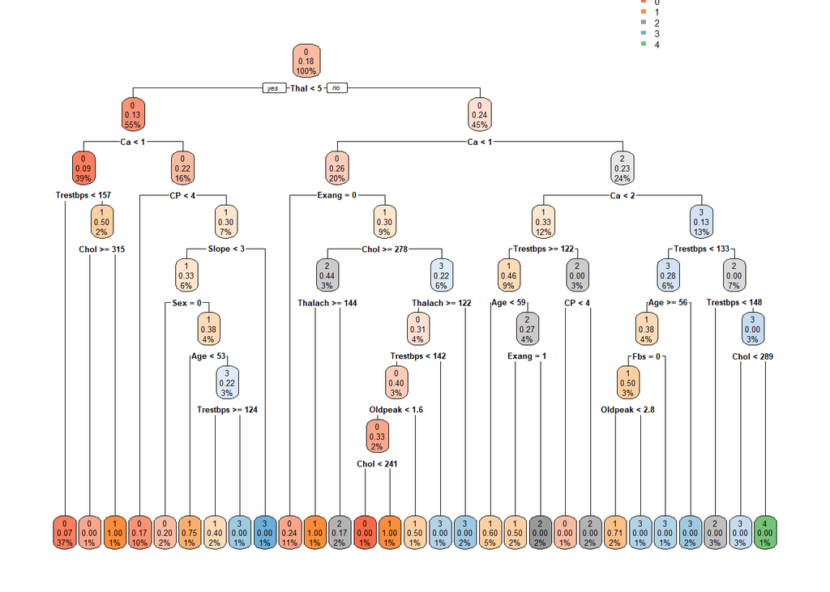

```r
#menggambarkan plot hasil decision tree menggunakan rpart.plot()
library(rpart.plot)
rpart.plot(fit,extra=106)
```

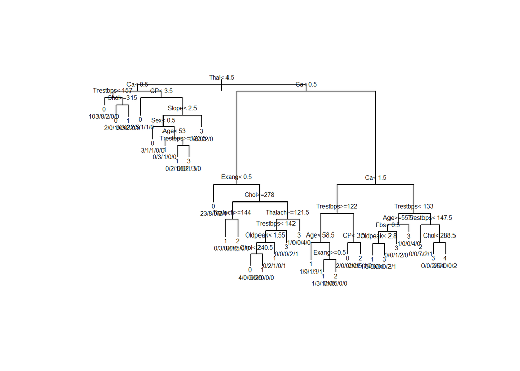

```r
#menggambarkan plot hasil decision tree menggunakan plot()
plot(fit,margin=0.08)
text(fit, use.n=TRUE,pretty=TRUE,cex=0.5)
```

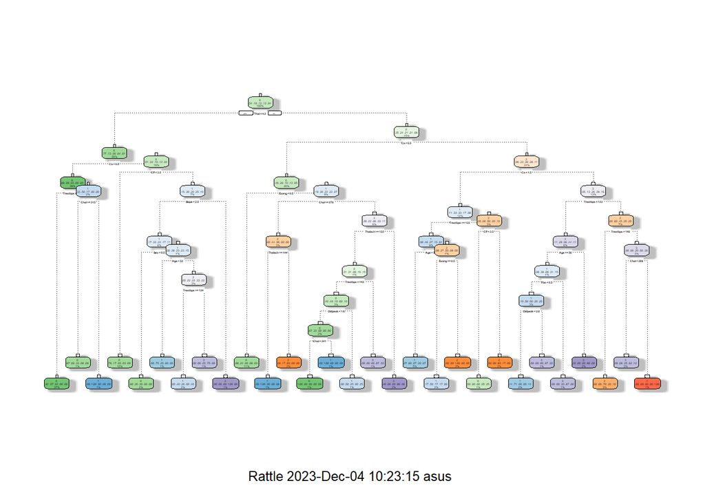

```r
#menggambarkan plot hasil decision tree menggunakan fungsi fancyRpartPlot() dari library rattle()
library(rattle)
fancyRpartPlot(fit)
```

### Step 5) : Membuat prediksi

Untuk membuat prediksi, menggunakan fungsi **predict()**.

```r
library(caret)
testData$Age <- as.numeric(testData$Age)
testData$Sex <- as.numeric(testData$Sex)
testData$CP <- as.numeric(testData$CP)
testData$Trestbps <- as.numeric(testData$Trestbps)
testData$Chol <- as.numeric(testData$Chol)
testData$Fbs <- as.numeric(testData$Fbs)
testData$Restecg <- as.numeric(testData$Restecg)
testData$Thalach <- as.numeric(testData$Thalach)
testData$Exang <- as.numeric(testData$Exang)
testData$Oldpeak <- as.numeric(testData$Oldpeak)
testData$Slope <- as.numeric(testData$Slope)
testData$Ca <- as.numeric(testData$Ca)
testData$Thal <- as.numeric(testData$Thal)
testData$Target <- factor(testData$Target)
str(testData)
```

```
## 'data.frame':    60 obs. of  14 variables:
##  $ Age     : num  67 67 56 57 48 49 69 60 44 59 ...
##  $ Sex     : num  1 1 1 1 0 1 0 1 1 1 ...
##  $ CP      : num  4 4 3 3 3 2 1 4 3 3 ...
##  $ Trestbps: num  160 120 130 150 130 130 140 117 130 150 ...
##  $ Chol    : num  286 229 256 168 275 266 239 230 233 212 ...
##  $ Fbs     : num  0 0 1 0 0 0 0 1 0 1 ...
##  $ Restecg : num  2 2 2 0 0 0 0 0 0 0 ...
##  $ Thalach : num  108 129 142 174 139 171 151 160 179 157 ...
##  $ Exang   : num  1 1 1 0 0 0 0 1 1 0 ...
##  $ Oldpeak : num  1.5 2.6 0.6 1.6 0.2 0.6 1.8 1.4 0.4 1.6 ...
##  $ Slope   : num  2 2 2 1 1 1 1 1 1 1 ...
##  $ Ca      : num  3 2 1 0 0 0 2 2 0 0 ...
##  $ Thal    : num  3 7 6 3 3 3 3 7 3 3 ...
##  $ Target  : Factor w/ 5 levels "0","1","2","3",..: 3 2 3 1 1 1 1 3 1 1 ...
```

```r
trainData$Age <- as.factor(trainData$Age)
trainData$Sex <- as.factor(trainData$Sex)
trainData$CP <- as.factor(trainData$CP)
trainData$Trestbps <- as.factor(trainData$Trestbps)
trainData$Chol <- as.factor(trainData$Chol)
trainData$Fbs <- as.factor(trainData$Fbs)
trainData$Restecg <- as.factor(trainData$Restecg)
trainData$Thalach <- as.factor(trainData$Thalach)
trainData$Exang <- as.factor(trainData$Exang)
trainData$Oldpeak <- as.factor(trainData$Oldpeak)
trainData$Slope <- as.factor(trainData$Slope)
trainData$Ca <- as.factor(trainData$Ca)
trainData$Thal <- as.factor(trainData$Thal)
trainData$Target <- as.factor(trainData$Target)
str(trainData)
```

```
## 'data.frame':    303 obs. of  14 variables:
##  $ Age     : Factor w/ 41 levels "29","34","35",..: 30 34 34 4 8 23 29 24 30 20 ...
##  $ Sex     : Factor w/ 2 levels "0","1": 2 2 2 2 1 2 1 1 2 2 ...
##  $ CP      : Factor w/ 4 levels "1","2","3","4": 1 4 4 3 2 2 4 4 4 4 ...
##  $ Trestbps: Factor w/ 50 levels "94","100","101",..: 32 41 15 23 23 15 29 15 23 29 ...
##  $ Chol    : Factor w/ 152 levels "126","131","141",..: 65 112 61 81 36 68 98 146 84 35 ...
##  $ Fbs     : Factor w/ 2 levels "0","1": 2 1 1 1 1 1 1 1 1 2 ...
##  $ Restecg : Factor w/ 3 levels "0","1","2": 3 3 3 1 3 1 3 1 3 3 ...
##  $ Thalach : Factor w/ 91 levels "71","88","90",..: 50 11 30 85 72 77 60 63 47 55 ...
##  $ Exang   : Factor w/ 2 levels "0","1": 1 2 2 1 1 1 1 2 1 2 ...
##  $ Oldpeak : Factor w/ 40 levels "0","0.1","0.2",..: 23 16 26 33 15 9 34 7 15 30 ...
##  $ Slope   : Factor w/ 3 levels "1","2","3": 3 2 2 3 1 1 3 1 2 3 ...
##  $ Ca      : Factor w/ 4 levels "0","1","2","3": 1 4 3 1 1 1 3 1 2 1 ...
##  $ Thal    : Factor w/ 4 levels "0","3","6","7": 3 2 4 2 2 2 2 2 4 4 ...
##  $ Target  : Factor w/ 5 levels "0","1","2","3",..: 1 3 2 1 1 1 4 1 3 2 ...
```

```r
str(trainData)
```

```
## 'data.frame':    303 obs. of  14 variables:
##  $ Age     : Factor w/ 41 levels "29","34","35",..: 30 34 34 4 8 23 29 24 30 20 ...
##  $ Sex     : Factor w/ 2 levels "0","1": 2 2 2 2 1 2 1 1 2 2 ...
##  $ CP      : Factor w/ 4 levels "1","2","3","4": 1 4 4 3 2 2 4 4 4 4 ...
##  $ Trestbps: Factor w/ 50 levels "94","100","101",..: 32 41 15 23 23 15 29 15 23 29 ...
##  $ Chol    : Factor w/ 152 levels "126","131","141",..: 65 112 61 81 36 68 98 146 84 35 ...
##  $ Fbs     : Factor w/ 2 levels "0","1": 2 1 1 1 1 1 1 1 1 2 ...
##  $ Restecg : Factor w/ 3 levels "0","1","2": 3 3 3 1 3 1 3 1 3 3 ...
##  $ Thalach : Factor w/ 91 levels "71","88","90",..: 50 11 30 85 72 77 60 63 47 55 ...
##  $ Exang   : Factor w/ 2 levels "0","1": 1 2 2 1 1 1 1 2 1 2 ...
##  $ Oldpeak : Factor w/ 40 levels "0","0.1","0.2",..: 23 16 26 33 15 9 34 7 15 30 ...
##  $ Slope   : Factor w/ 3 levels "1","2","3": 3 2 2 3 1 1 3 1 2 3 ...
##  $ Ca      : Factor w/ 4 levels "0","1","2","3": 1 4 3 1 1 1 3 1 2 1 ...
##  $ Thal    : Factor w/ 4 levels "0","3","6","7": 3 2 4 2 2 2 2 2 4 4 ...
##  $ Target  : Factor w/ 5 levels "0","1","2","3",..: 1 3 2 1 1 1 4 1 3 2 ...
```

```r
str(testData)
```

```
## 'data.frame':    60 obs. of  14 variables:
##  $ Age     : num  67 67 56 57 48 49 69 60 44 59 ...
##  $ Sex     : num  1 1 1 1 0 1 0 1 1 1 ...
##  $ CP      : num  4 4 3 3 3 2 1 4 3 3 ...
##  $ Trestbps: num  160 120 130 150 130 130 140 117 130 150 ...
##  $ Chol    : num  286 229 256 168 275 266 239 230 233 212 ...
##  $ Fbs     : num  0 0 1 0 0 0 0 1 0 1 ...
##  $ Restecg : num  2 2 2 0 0 0 0 0 0 0 ...
##  $ Thalach : num  108 129 142 174 139 171 151 160 179 157 ...
##  $ Exang   : num  1 1 1 0 0 0 0 1 1 0 ...
##  $ Oldpeak : num  1.5 2.6 0.6 1.6 0.2 0.6 1.8 1.4 0.4 1.6 ...
##  $ Slope   : num  2 2 2 1 1 1 1 1 1 1 ...
##  $ Ca      : num  3 2 1 0 0 0 2 2 0 0 ...
##  $ Thal    : num  3 7 6 3 3 3 3 7 3 3 ...
##  $ Target  : Factor w/ 5 levels "0","1","2","3",..: 3 2 3 1 1 1 1 3 1 1 ...
```

```r
prediksi <- predict(fit,newdata=testData,type="class")
prediksi
```

```
##  1  2  3  4  5  6  7  8  9 10 11 12 13 14 15 16 17 18 19 20 21 22 23 24 25 26
##  1  1  1  0  0  0  0  3  0  0  0  1  2  0  1  3  3  0  0  1  0  4  0  0  0  0
## 27 28 29 30 31 32 33 34 35 36 37 38 39 40 41 42 43 44 45 46 47 48 49 50 51 52
##  0  1  0  0  2  1  1  0  1  0  3  3  0  0  3  0  0  0  0  0  0  0  0  1  0  0
## 53 54 55 56 57 58 59 60
##  0  0  0  0  0  3  1  2
## Levels: 0 1 2 3 4
```

```r
table_mat <- table(testData$Target,prediksi)
table_mat
```

```
##    prediksi
##      0  1  2  3  4
##   0 31  0  0  0  0
##   1  5 10  0  0  0
##   2  0  2  2  1  0
##   3  0  0  0  6  0
##   4  1  0  1  0  1
```

```r
library(caret)
confusionMatrix(table(testData$Target, prediksi))
```

```
## Confusion Matrix and Statistics
##
##    prediksi
##      0  1  2  3  4
##   0 31  0  0  0  0
##   1  5 10  0  0  0
##   2  0  2  2  1  0
##   3  0  0  0  6  0
##   4  1  0  1  0  1
##
## Overall Statistics
##
##                Accuracy : 0.8333
##                  95% CI : (0.7148, 0.9171)
##     No Information Rate : 0.6167
##     P-Value [Acc > NIR] : 0.0002349
##
##                   Kappa : 0.7289
##
##  Mcnemar's Test P-Value : NA
##
## Statistics by Class:
##
##                      Class: 0 Class: 1 Class: 2 Class: 3 Class: 4
## Sensitivity            0.8378   0.8333  0.66667   0.8571  1.00000
## Specificity            1.0000   0.8958  0.94737   1.0000  0.96610
## Pos Pred Value         1.0000   0.6667  0.40000   1.0000  0.33333
## Neg Pred Value         0.7931   0.9556  0.98182   0.9815  1.00000
## Prevalence             0.6167   0.2000  0.05000   0.1167  0.01667
## Detection Rate         0.5167   0.1667  0.03333   0.1000  0.01667
## Detection Prevalence   0.5167   0.2500  0.08333   0.1000  0.05000
## Balanced Accuracy      0.9189   0.8646  0.80702   0.9286  0.98305
```

## B. Membangun Decision Tree menggunakan algoritma C45 = J48 dari Weka

### Step 1) Import Data

Data yang akan digunakan ialah data heart disease. Adapun datanya adalah sebagai berikut:

```r
trainData <- read.csv("D:\\KULIAH\\Dataset\\Pen data\\heart_disease_dataset.csv")
str(trainData)
```

```
## 'data.frame':    303 obs. of  14 variables:
##  $ Age     : int  63 67 67 37 41 56 62 57 63 53 ...
##  $ Sex     : int  1 1 1 1 0 1 0 0 1 1 ...
##  $ CP      : int  1 4 4 3 2 2 4 4 4 4 ...
##  $ Trestbps: int  145 160 120 130 130 120 140 120 130 140 ...
##  $ Chol    : int  233 286 229 250 204 236 268 354 254 203 ...
##  $ Fbs     : int  1 0 0 0 0 0 0 0 0 1 ...
##  $ Restecg : int  2 2 2 0 2 0 2 0 2 2 ...
##  $ Thalach : int  150 108 129 187 172 178 160 163 147 155 ...
##  $ Exang   : int  0 1 1 0 0 0 0 1 0 1 ...
##  $ Oldpeak : num  2.3 1.5 2.6 3.5 1.4 0.8 3.6 0.6 1.4 3.1 ...
##  $ Slope   : int  3 2 2 3 1 1 3 1 2 3 ...
##  $ Ca      : int  0 3 2 0 0 0 2 0 1 0 ...
##  $ Thal    : int  6 3 7 3 3 3 3 3 7 7 ...
##  $ Target  : int  0 2 1 0 0 0 3 0 2 1 ...
```

### Step 2) Preprocessing Data

Beberapa tahapan preprosesing data yang perlu dilakukan :

1. Pastikan dataset telah memiliki kelas tujuan yang bertipe kategorikal (kasus klasifikasi).
2. Tidak ada data yang NA / bernilai null
3. Tentukan variabel-variabel yang akan digunakan untuk proses klasifikasi. Variabel yang tidak digunakan dapat dihilangkan.
4. Pada tahap ini perhatikan dataset yang digunakan. Tentukan class tujuan dan ubah tipe dari class tujuan.
5. Jika diperlukan lakukan proses suffle dataset (mengacak kembali dataset), terutama jika dataset yang digunakan akan digunakan untuk training dan testing.

Untuk kasus ini tahapan preprosesing yang dilakukan adalah membuat variabel **Target** menjadi bertipe factor karena merupakan atribut/variabel kategorikal sebagai kelas tujuan.

```r
trainData
```

```
##     Age Sex CP Trestbps Chol Fbs Restecg Thalach Exang Oldpeak Slope Ca Thal
## 1    63   1  1      145  233   1       2     150     0     2.3     3  0    6
## 2    67   1  4      160  286   0       2     108     1     1.5     2  3    3
## 3    67   1  4      120  229   0       2     129     1     2.6     2  2    7
## 4    37   1  3      130  250   0       0     187     0     3.5     3  0    3
## 5    41   0  2      130  204   0       2     172     0     1.4     1  0    3
## 6    56   1  2      120  236   0       0     178     0     0.8     1  0    3
## 7    62   0  4      140  268   0       2     160     0     3.6     3  2    3
## 8    57   0  4      120  354   0       0     163     1     0.6     1  0    3
## 9    63   1  4      130  254   0       2     147     0     1.4     2  1    7
## 10   53   1  4      140  203   1       2     155     1     3.1     3  0    7
## 11   57   1  4      140  192   0       0     148     0     0.4     2  0    6
## 12   56   0  2      140  294   0       2     153     0     1.3     2  0    3
## 13   56   1  3      130  256   1       2     142     1     0.6     2  1    6
## 14   44   1  2      120  263   0       0     173     0     0.0     1  0    7
```

[output cut: 593 more lines]

### Step 3) Membuat training data dan testing data

Data testing dibuat pada file terpisah

```r
testData <- read.csv("D:\\KULIAH\\Dataset\\Pen data\\testData.csv")
testData$Target <- factor(testData$Target)
str(testData)
```

```
## 'data.frame':    60 obs. of  14 variables:
##  $ Age     : int  67 67 56 57 48 49 69 60 44 59 ...
##  $ Sex     : int  1 1 1 1 0 1 0 1 1 1 ...
##  $ CP      : int  4 4 3 3 3 2 1 4 3 3 ...
##  $ Trestbps: int  160 120 130 150 130 130 140 117 130 150 ...
##  $ Chol    : int  286 229 256 168 275 266 239 230 233 212 ...
##  $ Fbs     : int  0 0 1 0 0 0 0 1 0 1 ...
##  $ Restecg : int  2 2 2 0 0 0 0 0 0 0 ...
##  $ Thalach : int  108 129 142 174 139 171 151 160 179 157 ...
##  $ Exang   : int  1 1 1 0 0 0 0 1 1 0 ...
##  $ Oldpeak : num  1.5 2.6 0.6 1.6 0.2 0.6 1.8 1.4 0.4 1.6 ...
##  $ Slope   : int  2 2 2 1 1 1 1 1 1 1 ...
##  $ Ca      : int  3 2 1 0 0 0 2 2 0 0 ...
##  $ Thal    : int  3 7 6 3 3 3 3 7 3 3 ...
##  $ Target  : Factor w/ 5 levels "0","1","2","3",..: 3 2 3 1 1 1 1 3 1 1 ...
```

```r
testData
```

```
##    Age Sex CP Trestbps Chol Fbs Restecg Thalach Exang Oldpeak Slope Ca Thal
## 1   67   1  4      160  286   0       2     108     1     1.5     2  3    3
## 2   67   1  4      120  229   0       2     129     1     2.6     2  2    7
## 3   56   1  3      130  256   1       2     142     1     0.6     2  1    6
## 4   57   1  3      150  168   0       0     174     0     1.6     1  0    3
## 5   48   0  3      130  275   0       0     139     0     0.2     1  0    3
## 6   49   1  2      130  266   0       0     171     0     0.6     1  0    3
## 7   69   0  1      140  239   0       0     151     0     1.8     1  2    3
## 8   60   1  4      117  230   1       0     160     1     1.4     1  2    7
## 9   44   1  3      130  233   0       0     179     1     0.4     1  0    3
## 10  59   1  3      150  212   1       0     157     0     1.6     1  0    3
## 11  58   1  3      112  230   0       2     165     0     2.5     2  1    7
## 12  54   1  4      124  266   0       2     109     1     2.2     2  1    7
## 13  60   1  4      145  282   0       2     142     1     2.8     2  2    7
## 14  65   0  3      155  269   0       0     148     0     0.8     1  0    3
```

[output cut: 107 more lines]

### Step 4) : Membangun model

untuk membangun model, gunakan fungsi J48 merupakan algoritma C4.5 dari library RWeka. Sintaknya adalah :

```r
Sys.setenv('JAVA_HOME'="C:/Program Files/Java/jdk-12.0.2/")
library(RWeka)
library(rJava)
##install.packages("rJava")

##default:
trainData$Age <- factor(trainData$Age)
trainData$Sex <- factor(trainData$Sex)
trainData$CP <- factor(trainData$CP)
trainData$Trestbps <- factor(trainData$Trestbps)
trainData$Chol <- factor(trainData$Chol)
trainData$Fbs <- factor(trainData$Fbs)
trainData$Restecg <- factor(trainData$Restecg)
trainData$Thalach <- factor(trainData$Thalach)
trainData$Exang <- factor(trainData$Exang)
trainData$Oldpeak <- factor(trainData$Oldpeak)
trainData$Slope <- factor(trainData$Slope)
trainData$Ca <- factor(trainData$Ca)
trainData$Thal <- factor(trainData$Thal)
trainData$Target <- factor(trainData$Target)
str(trainData)
```

```
## 'data.frame':    303 obs. of  14 variables:
##  $ Age     : Factor w/ 41 levels "29","34","35",..: 30 34 34 4 8 23 29 24 30 20 ...
##  $ Sex     : Factor w/ 2 levels "0","1": 2 2 2 2 1 2 1 1 2 2 ...
##  $ CP      : Factor w/ 4 levels "1","2","3","4": 1 4 4 3 2 2 4 4 4 4 ...
##  $ Trestbps: Factor w/ 50 levels "94","100","101",..: 32 41 15 23 23 15 29 15 23 29 ...
##  $ Chol    : Factor w/ 152 levels "126","131","141",..: 65 112 61 81 36 68 98 146 84 35 ...
##  $ Fbs     : Factor w/ 2 levels "0","1": 2 1 1 1 1 1 1 1 1 2 ...
##  $ Restecg : Factor w/ 3 levels "0","1","2": 3 3 3 1 3 1 3 1 3 3 ...
##  $ Thalach : Factor w/ 91 levels "71","88","90",..: 50 11 30 85 72 77 60 63 47 55 ...
##  $ Exang   : Factor w/ 2 levels "0","1": 1 2 2 1 1 1 1 2 1 2 ...
##  $ Oldpeak : Factor w/ 40 levels "0","0.1","0.2",..: 23 16 26 33 15 9 34 7 15 30 ...
##  $ Slope   : Factor w/ 3 levels "1","2","3": 3 2 2 3 1 1 3 1 2 3 ...
##  $ Ca      : Factor w/ 4 levels "0","1","2","3": 1 4 3 1 1 1 3 1 2 1 ...
##  $ Thal    : Factor w/ 4 levels "0","3","6","7": 3 2 4 2 2 2 2 2 4 4 ...
##  $ Target  : Factor w/ 5 levels "0","1","2","3",..: 1 3 2 1 1 1 4 1 3 2 ...
```

```r
# Tentukan formula
formula <- Target ~ Age + Sex + CP + Trestbps + Chol + Fbs + Restecg + Thalach + Exang + Oldpeak + Slope + Ca + Thal

# Buat model J48
fit <- J48(formula, data = trainData)
print(fit)
```

```
## J48 pruned tree
## ------------------
##
## Thal = 0: 0 (2.0/1.0)
## Thal = 3: 0 (166.0/37.0)
## Thal = 6
## |   Oldpeak = 0: 0 (3.0/1.0)
## |   Oldpeak = 0.1: 0 (0.0)
## |   Oldpeak = 0.2: 0 (0.0)
## |   Oldpeak = 0.3: 0 (0.0)
## |   Oldpeak = 0.4: 0 (1.0)
## |   Oldpeak = 0.5: 0 (0.0)
## |   Oldpeak = 0.6: 1 (3.0/1.0)
## |   Oldpeak = 0.7: 0 (0.0)
## |   Oldpeak = 0.8: 0 (0.0)
## |   Oldpeak = 0.9: 0 (0.0)
## |   Oldpeak = 1: 3 (1.0)
## |   Oldpeak = 1.1: 0 (0.0)
## |   Oldpeak = 1.2: 0 (0.0)
## |   Oldpeak = 1.3: 0 (0.0)
## |   Oldpeak = 1.4: 0 (0.0)
## |   Oldpeak = 1.5: 0 (1.0)
## |   Oldpeak = 1.6: 0 (0.0)
## |   Oldpeak = 1.8: 2 (1.0)
## |   Oldpeak = 1.9: 0 (0.0)
## |   Oldpeak = 2: 4 (1.0)
## |   Oldpeak = 2.1: 1 (1.0)
## |   Oldpeak = 2.2: 2 (1.0)
## |   Oldpeak = 2.3: 0 (2.0)
## |   Oldpeak = 2.4: 0 (0.0)
## |   Oldpeak = 2.5: 0 (0.0)
## |   Oldpeak = 2.6: 0 (0.0)
## |   Oldpeak = 2.8: 2 (2.0)
## |   Oldpeak = 2.9: 0 (0.0)
## |   Oldpeak = 3: 0 (0.0)
## |   Oldpeak = 3.1: 0 (0.0)
## |   Oldpeak = 3.2: 0 (0.0)
## |   Oldpeak = 3.4: 0 (0.0)
## |   Oldpeak = 3.5: 0 (0.0)
## |   Oldpeak = 3.6: 0 (0.0)
```

[output cut: 148 more lines]

```
## |   Chol = 340: 1 (0.0)
## |   Chol = 341: 2 (1.0)
## |   Chol = 342: 1 (0.0)
## |   Chol = 353: 3 (1.0)
## |   Chol = 354: 1 (0.0)
## |   Chol = 360: 1 (0.0)
## |   Chol = 394: 1 (0.0)
## |   Chol = 407: 4 (1.0)
## |   Chol = 409: 2 (1.0)
## |   Chol = 417: 1 (0.0)
## |   Chol = 564: 0 (1.0)
##
## Number of Leaves  :  194
##
## Size of the tree :   197
```

```r
summary(fit)
```

```
##
## === Summary ===
##
## Correctly Classified Instances         238               78.5479 %
## Incorrectly Classified Instances        65               21.4521 %
## Kappa statistic                          0.6262
## Mean absolute error                      0.1216
## Root mean squared error                  0.2466
## Relative absolute error                 46.9747 %
## Root relative squared error             68.6697 %
## Total Number of Instances              303
##
## === Confusion Matrix ===
##
##    a   b   c   d   e   <-- classified as
##  164   0   0   0   0 |   a = 0
##   26  28   0   1   0 |   b = 1
##   13   4  19   0   0 |   c = 2
##   11   3   3  18   0 |   d = 3
##    3   0   1   0   9 |   e = 4
```

```r
## menggambarkan plot
plot(fit)
```

[output not shown]

```r
if(require("partykit", quietly = TRUE)) plot(fit)
table(predict(fit), trainData$Target)
```

```
##
##       0   1   2   3   4
##   0 164  26  13  11   3
##   1   0  28   4   3   0
##   2   0   0  19   3   1
##   3   0   1   0  18   0
##   4   0   0   0   0   9
```

### Step 5) : Membuat prediksi

Untuk membuat prediksi, menggunakan fungsi predict(). Secara default syntax untuk melakukan prediksi dari R decision tree adalah :

```r
testData <- read.csv("D:\\KULIAH\\Dataset\\Pen data\\testData.csv")
testData$Target <- factor(testData$Target)
## str(testData)
testData$Age <- factor(testData$Age)
testData$Sex <- factor(testData$Sex)
testData$CP <- factor(testData$CP)
testData$Trestbps <- factor(testData$Trestbps)
testData$Chol <- factor(testData$Chol)
testData$Fbs <- factor(testData$Fbs)
testData$Restecg <- factor(testData$Restecg)
testData$Thalach <- factor(testData$Thalach)
testData$Exang <- factor(testData$Exang)
testData$Oldpeak <- factor(testData$Oldpeak)
testData$Slope <- factor(testData$Slope)
testData$Ca <- factor(testData$Ca)
testData$Thal <- factor(testData$Thal)
testData$Target <- factor(testData$Target)
str(testData)
```

```
## 'data.frame':    60 obs. of  14 variables:
##  $ Age     : Factor w/ 30 levels "35","39","40",..: 27 27 17 18 9 10 29 21 6 20 ...
##  $ Sex     : Factor w/ 2 levels "0","1": 2 2 2 2 1 2 1 2 2 2 ...
##  $ CP      : Factor w/ 4 levels "1","2","3","4": 4 4 3 3 3 2 1 4 3 3 ...
##  $ Trestbps: Factor w/ 31 levels "100","101","102",..: 28 10 16 25 16 16 21 8 16 25 ...
##  $ Chol    : Factor w/ 50 levels "149","164","168",..: 43 20 31 3 40 34 23 21 22 13 ...
##  $ Fbs     : Factor w/ 2 levels "0","1": 1 1 2 1 1 1 1 2 1 2 ...
##  $ Restecg : Factor w/ 2 levels "0","2": 2 2 2 1 1 1 1 1 1 1 ...
##  $ Thalach : Factor w/ 44 levels "88","90","105",..: 4 9 15 39 13 36 21 27 41 25 ...
##  $ Exang   : Factor w/ 2 levels "0","1": 2 2 2 1 1 1 1 2 2 1 ...
##  $ Oldpeak : Factor w/ 24 levels "0","0.2","0.4",..: 10 19 4 11 2 4 12 9 3 11 ...
##  $ Slope   : Factor w/ 3 levels "1","2","3": 2 2 2 1 1 1 1 1 1 1 ...
##  $ Ca      : Factor w/ 4 levels "0","1","2","3": 4 3 2 1 1 1 3 3 1 1 ...
##  $ Thal    : Factor w/ 3 levels "3","6","7": 1 3 2 1 1 1 1 3 1 1 ...
##  $ Target  : Factor w/ 5 levels "0","1","2","3",..: 3 2 3 1 1 1 1 3 1 1 ...
```

```r
prediksi <- predict(fit,newdata=testData,type="class")
prediksi
```

```
##  [1] 0 0 0 0 0 0 0 0 0 0 2 0 4 0 0 3 0 0 0 0 0 0 0 0 0 0 0 0 0 0 0 0 0 0 0 0 1 0
## [39] 0 0 1 0 0 0 0 0 0 0 0 0 0 0 0 0 0 0 0 0 0 2
## Levels: 0 1 2 3 4
```

```r
table_mat <- table(testData$Target,prediksi)
table_mat
```

```
##    prediksi
##      0  1  2  3  4
##   0 31  0  0  0  0
##   1 15  0  0  0  0
##   2  3  0  1  0  1
##   3  3  2  0  1  0
##   4  2  0  1  0  0
```

```r
library(caret)
confusionMatrix(table(testData$Target,prediksi))
```

```
## Confusion Matrix and Statistics
##
##    prediksi
##      0  1  2  3  4
##   0 31  0  0  0  0
##   1 15  0  0  0  0
##   2  3  0  1  0  1
##   3  3  2  0  1  0
##   4  2  0  1  0  0
##
## Overall Statistics
##
##                Accuracy : 0.55
##                  95% CI : (0.4161, 0.6788)
##     No Information Rate : 0.9
##     P-Value [Acc > NIR] : 1
##
##                   Kappa : 0.1369
##
##  Mcnemar's Test P-Value : NA
##
## Statistics by Class:
##
##                      Class: 0 Class: 1 Class: 2 Class: 3 Class: 4
## Sensitivity            0.5741  0.00000  0.50000  1.00000  0.00000
## Specificity            1.0000  0.74138  0.93103  0.91525  0.94915
## Pos Pred Value         1.0000  0.00000  0.20000  0.16667  0.00000
## Neg Pred Value         0.2069  0.95556  0.98182  1.00000  0.98246
## Prevalence             0.9000  0.03333  0.03333  0.01667  0.01667
## Detection Rate         0.5167  0.00000  0.01667  0.01667  0.00000
## Detection Prevalence   0.5167  0.25000  0.08333  0.10000  0.05000
## Balanced Accuracy      0.7870  0.37069  0.71552  0.95763  0.47458
```

```r
control <- Weka_control(R=TRUE,M=2)
    tune_fit <- J48(Target~.,data=trainData,control=Weka_control(R=FALSE,M=3))
    tune_fit
```

```
## J48 pruned tree
## ------------------
##
## Thal = 0: 0 (2.0/1.0)
## Thal = 3: 0 (166.0/37.0)
## Thal = 6
## |   Oldpeak = 0: 0 (3.0/1.0)
## |   Oldpeak = 0.1: 0 (0.0)
## |   Oldpeak = 0.2: 0 (0.0)
## |   Oldpeak = 0.3: 0 (0.0)
## |   Oldpeak = 0.4: 0 (1.0)
## |   Oldpeak = 0.5: 0 (0.0)
## |   Oldpeak = 0.6: 1 (3.0/1.0)
## |   Oldpeak = 0.7: 0 (0.0)
## |   Oldpeak = 0.8: 0 (0.0)
## |   Oldpeak = 0.9: 0 (0.0)
## |   Oldpeak = 1: 3 (1.0)
## |   Oldpeak = 1.1: 0 (0.0)
## |   Oldpeak = 1.2: 0 (0.0)
## |   Oldpeak = 1.3: 0 (0.0)
## |   Oldpeak = 1.4: 0 (0.0)
## |   Oldpeak = 1.5: 0 (1.0)
## |   Oldpeak = 1.6: 0 (0.0)
## |   Oldpeak = 1.8: 2 (1.0)
## |   Oldpeak = 1.9: 0 (0.0)
## |   Oldpeak = 2: 4 (1.0)
## |   Oldpeak = 2.1: 1 (1.0)
## |   Oldpeak = 2.2: 2 (1.0)
## |   Oldpeak = 2.3: 0 (2.0)
## |   Oldpeak = 2.4: 0 (0.0)
## |   Oldpeak = 2.5: 0 (0.0)
## |   Oldpeak = 2.6: 0 (0.0)
## |   Oldpeak = 2.8: 2 (2.0)
## |   Oldpeak = 2.9: 0 (0.0)
## |   Oldpeak = 3: 0 (0.0)
## |   Oldpeak = 3.1: 0 (0.0)
## |   Oldpeak = 3.2: 0 (0.0)
## |   Oldpeak = 3.4: 0 (0.0)
## |   Oldpeak = 3.5: 0 (0.0)
## |   Oldpeak = 3.6: 0 (0.0)
```

[output cut: 148 more lines]

```
## |   Chol = 340: 1 (0.0)
## |   Chol = 341: 2 (1.0)
## |   Chol = 342: 1 (0.0)
## |   Chol = 353: 3 (1.0)
## |   Chol = 354: 1 (0.0)
## |   Chol = 360: 1 (0.0)
## |   Chol = 394: 1 (0.0)
## |   Chol = 407: 4 (1.0)
## |   Chol = 409: 2 (1.0)
## |   Chol = 417: 1 (0.0)
## |   Chol = 564: 0 (1.0)
##
## Number of Leaves  :  194
##
## Size of the tree :   197
```

```r
plot(tune_fit)
```

[output not shown]

```r
prediksifit <- predict(tune_fit,newdata=testData)
    prediksifit
```

```
##  [1] 0 0 0 0 0 0 0 0 0 0 2 0 4 0 0 3 0 0 0 0 0 0 0 0 0 0 0 0 0 0 0 0 0 0 0 0 1 0
## [39] 0 0 1 0 0 0 0 0 0 0 0 0 0 0 0 0 0 0 0 0 0 2
## Levels: 0 1 2 3 4
```

```r
confusionMatrix(table(testData$Target,prediksifit))
```

```
## Confusion Matrix and Statistics
##
##    prediksifit
##      0  1  2  3  4
##   0 31  0  0  0  0
##   1 15  0  0  0  0
##   2  3  0  1  0  1
##   3  3  2  0  1  0
##   4  2  0  1  0  0
##
## Overall Statistics
##
##                Accuracy : 0.55
##                  95% CI : (0.4161, 0.6788)
##     No Information Rate : 0.9
##     P-Value [Acc > NIR] : 1
##
##                   Kappa : 0.1369
##
##  Mcnemar's Test P-Value : NA
##
## Statistics by Class:
##
##                      Class: 0 Class: 1 Class: 2 Class: 3 Class: 4
## Sensitivity            0.5741  0.00000  0.50000  1.00000  0.00000
## Specificity            1.0000  0.74138  0.93103  0.91525  0.94915
## Pos Pred Value         1.0000  0.00000  0.20000  0.16667  0.00000
## Neg Pred Value         0.2069  0.95556  0.98182  1.00000  0.98246
## Prevalence             0.9000  0.03333  0.03333  0.01667  0.01667
## Detection Rate         0.5167  0.00000  0.01667  0.01667  0.00000
## Detection Prevalence   0.5167  0.25000  0.08333  0.10000  0.05000
## Balanced Accuracy      0.7870  0.37069  0.71552  0.95763  0.47458
```

## C. Membangun Decision Tree menggunakan algoritma PART = PART dari RWeka

### Step: Membangun model

```r
# Tentukan formula
formula <- Target ~ Age + Sex + CP + Trestbps + Chol + Fbs + Restecg + Thalach + Exang + Oldpeak + Slope + Ca + Thal

fit <- PART(formula, data = trainData)
print(fit)
```

```
## PART decision list
## ------------------
##
## Thal = 3 AND
## Ca = 0: 0 (117.0/13.0)
##
## Chol = 234: 0 (4.0/2.0)
##
## Chol = 254: 2 (4.0/1.0)
##
## Chol = 282: 1 (4.0/2.0)
##
## Chol = 177: 0 (3.0/2.0)
##
## Chol = 201: 0 (3.0)
##
## Chol = 203: 0 (3.0/2.0)
##
## Chol = 229: 1 (3.0)
##
## Chol = 230: 1 (3.0/2.0)
##
## Chol = 233: 0 (3.0/1.0)
##
## Chol = 239: 0 (3.0/2.0)
##
## Chol = 246: 0 (3.0/2.0)
##
## Chol = 258: 0 (3.0/2.0)
##
## Chol = 263: 0 (3.0/1.0)
##
## Chol = 269: 0 (3.0/2.0)
##
## Chol = 274: 3 (3.0/1.0)
##
## Chol = 288: 0 (3.0/2.0)
##
## Chol = 309: 0 (3.0/2.0)
##
## Chol = 188: 2 (2.0/1.0)
##
## Chol = 193: 0 (2.0/1.0)
##
## Chol = 197: 0 (2.0/1.0)
##
## Chol = 198: 0 (2.0/1.0)
##
## Chol = 199: 0 (2.0)
##
## Chol = 204: 1 (2.0/1.0)
##
## Chol = 206: 3 (2.0/1.0)
##
## Chol = 207: 0 (2.0/1.0)
##
## Chol = 212 AND
## Slope = 1: 2 (2.0/1.0)
##
## : 0 (114.0/77.0)
##
## Number of Rules  :   28
```

```r
summary(fit)
```

```
##
## === Summary ===
##
## Correctly Classified Instances         179               59.0759 %
## Incorrectly Classified Instances       124               40.9241 %
## Kappa statistic                          0.1668
## Mean absolute error                      0.1945
## Root mean squared error                  0.3118
## Relative absolute error                 75.1068 %
## Root relative squared error             86.8306 %
## Total Number of Instances              303
##
## === Confusion Matrix ===
##
##    a   b   c   d   e   <-- classified as
##  164   0   0   0   0 |   a = 0
##   47   7   0   1   0 |   b = 1
##   28   3   5   0   0 |   c = 2
##   28   1   3   3   0 |   d = 3
##   11   1   0   1   0 |   e = 4
```

```r
# Tentukan formula
#formula <- Target ~ Age + Sex + CP + Trestbps + Chol + Fbs + Restecg + Thalach + Exang + Oldpeak + Slope + Ca + Thal

#fit <- PART(formula, data = trainData)
#print(fit)
```

```r
table(predict(fit), trainData$Target)
```

```
##
##       0   1   2   3   4
##   0 164  47  28  28  11
##   1   0   7   3   1   1
##   2   0   0   5   3   0
##   3   0   1   0   3   1
##   4   0   0   0   0   0
```

### Step: Membuat prediksi

Untuk membuat prediksi, menggunakan fungsi **predict()**.

```r
testData <- read.csv("D:\\KULIAH\\Dataset\\Pen data\\testData.csv")

testData$Age <- factor(testData$Age)
testData$Sex <- factor(testData$Sex)
testData$CP <- factor(testData$CP)
testData$Trestbps <- factor(testData$Trestbps)
testData$Chol <- factor(testData$Chol)
testData$Fbs <- factor(testData$Fbs)
testData$Restecg <- factor(testData$Restecg)
testData$Thalach <- factor(testData$Thalach)
testData$Exang <- factor(testData$Exang)
testData$Oldpeak <- factor(testData$Oldpeak)
testData$Slope <- factor(testData$Slope)
testData$Ca <- factor(testData$Ca)
testData$Thal <- factor(testData$Thal)
testData$Target <- factor(testData$Target)
str(testData)
```

```
## 'data.frame':    60 obs. of  14 variables:
##  $ Age     : Factor w/ 30 levels "35","39","40",..: 27 27 17 18 9 10 29 21 6 20 ...
##  $ Sex     : Factor w/ 2 levels "0","1": 2 2 2 2 1 2 1 2 2 2 ...
##  $ CP      : Factor w/ 4 levels "1","2","3","4": 4 4 3 3 3 2 1 4 3 3 ...
##  $ Trestbps: Factor w/ 31 levels "100","101","102",..: 28 10 16 25 16 16 21 8 16 25 ...
##  $ Chol    : Factor w/ 50 levels "149","164","168",..: 43 20 31 3 40 34 23 21 22 13 ...
##  $ Fbs     : Factor w/ 2 levels "0","1": 1 1 2 1 1 1 1 2 1 2 ...
##  $ Restecg : Factor w/ 2 levels "0","2": 2 2 2 1 1 1 1 1 1 1 ...
##  $ Thalach : Factor w/ 44 levels "88","90","105",..: 4 9 15 39 13 36 21 27 41 25 ...
##  $ Exang   : Factor w/ 2 levels "0","1": 2 2 2 1 1 1 1 2 2 1 ...
##  $ Oldpeak : Factor w/ 24 levels "0","0.2","0.4",..: 10 19 4 11 2 4 12 9 3 11 ...
##  $ Slope   : Factor w/ 3 levels "1","2","3": 2 2 2 1 1 1 1 1 1 1 ...
##  $ Ca      : Factor w/ 4 levels "0","1","2","3": 4 3 2 1 1 1 3 3 1 1 ...
##  $ Thal    : Factor w/ 3 levels "3","6","7": 1 3 2 1 1 1 1 3 1 1 ...
##  $ Target  : Factor w/ 5 levels "0","1","2","3",..: 3 2 3 1 1 1 1 3 1 1 ...
```

```r
prediksi <- predict(fit,newdata=testData,type="class")
prediksi
```

```
##  [1] 0 0 0 0 0 0 0 0 0 0 0 0 0 1 0 0 0 0 0 0 0 0 0 0 0 0 0 0 0 0 0 0 0 0 3 0 0 0
## [39] 0 0 0 0 2 0 1 0 0 2 0 0 0 0 0 0 0 0 0 0 0 0
## Levels: 0 1 2 3 4
```

```r
table_mat <- table(testData$Target,prediksi)
table_mat
```

```
##    prediksi
##      0  1  2  3  4
##   0 28  1  2  0  0
##   1 13  1  0  1  0
##   2  5  0  0  0  0
##   3  6  0  0  0  0
##   4  3  0  0  0  0
```

```r
library(caret)
confusionMatrix(table(testData$Target,prediksi))
```

```
## Confusion Matrix and Statistics
##
##    prediksi
##      0  1  2  3  4
##   0 28  1  2  0  0
##   1 13  1  0  1  0
##   2  5  0  0  0  0
##   3  6  0  0  0  0
##   4  3  0  0  0  0
##
## Overall Statistics
##
##                Accuracy : 0.4833
##                  95% CI : (0.3523, 0.6161)
##     No Information Rate : 0.9167
##     P-Value [Acc > NIR] : 1
##
##                   Kappa : -0.0059
##
##  Mcnemar's Test P-Value : NA
##
## Statistics by Class:
##
##                      Class: 0 Class: 1 Class: 2 Class: 3 Class: 4
## Sensitivity           0.50909  0.50000  0.00000  0.00000       NA
## Specificity           0.40000  0.75862  0.91379  0.89831     0.95
## Pos Pred Value        0.90323  0.06667  0.00000  0.00000       NA
## Neg Pred Value        0.06897  0.97778  0.96364  0.98148       NA
## Prevalence            0.91667  0.03333  0.03333  0.01667     0.00
## Detection Rate        0.46667  0.01667  0.00000  0.00000     0.00
## Detection Prevalence  0.51667  0.25000  0.08333  0.10000     0.05
## Balanced Accuracy     0.45455  0.62931  0.45690  0.44915       NA
```

## D. Membangun Decision Tree menggunakan algoritma CTREE Fungsi CTREE dari Package Party

### Step: Membangun model decision Tree CTREE

untuk membangun model, gunakan fungsi **ctree** (conditional inference trees) dari library **party**.

```r
library(party)
trainData$Age <- factor(trainData$Age)
trainData$Sex <- factor(trainData$Sex)
trainData$CP <- factor(trainData$CP)
trainData$Trestbps <- factor(trainData$Trestbps)
trainData$Chol <- factor(trainData$Chol)
trainData$Fbs <- factor(trainData$Fbs)
trainData$Restecg <- factor(trainData$Restecg)
trainData$Thalach <- factor(trainData$Thalach)
trainData$Exang <- factor(trainData$Exang)
trainData$Oldpeak <- factor(trainData$Oldpeak)
trainData$Slope <- factor(trainData$Slope)
trainData$Ca <- factor(trainData$Ca)
trainData$Thal <- factor(trainData$Thal)
trainData$Target <- factor(trainData$Target)
str(trainData)
```

```
## 'data.frame':    303 obs. of  14 variables:
##  $ Age     : Factor w/ 41 levels "29","34","35",..: 30 34 34 4 8 23 29 24 30 20 ...
##  $ Sex     : Factor w/ 2 levels "0","1": 2 2 2 2 1 2 1 1 2 2 ...
##  $ CP      : Factor w/ 4 levels "1","2","3","4": 1 4 4 3 2 2 4 4 4 4 ...
##  $ Trestbps: Factor w/ 50 levels "94","100","101",..: 32 41 15 23 23 15 29 15 23 29 ...
##  $ Chol    : Factor w/ 152 levels "126","131","141",..: 65 112 61 81 36 68 98 146 84 35 ...
##  $ Fbs     : Factor w/ 2 levels "0","1": 2 1 1 1 1 1 1 1 1 2 ...
##  $ Restecg : Factor w/ 3 levels "0","1","2": 3 3 3 1 3 1 3 1 3 3 ...
##  $ Thalach : Factor w/ 91 levels "71","88","90",..: 50 11 30 85 72 77 60 63 47 55 ...
##  $ Exang   : Factor w/ 2 levels "0","1": 1 2 2 1 1 1 1 2 1 2 ...
##  $ Oldpeak : Factor w/ 40 levels "0","0.1","0.2",..: 23 16 26 33 15 9 34 7 15 30 ...
##  $ Slope   : Factor w/ 3 levels "1","2","3": 3 2 2 3 1 1 3 1 2 3 ...
##  $ Ca      : Factor w/ 4 levels "0","1","2","3": 1 4 3 1 1 1 3 1 2 1 ...
##  $ Thal    : Factor w/ 4 levels "0","3","6","7": 3 2 4 2 2 2 2 2 4 4 ...
##  $ Target  : Factor w/ 5 levels "0","1","2","3",..: 1 3 2 1 1 1 4 1 3 2 ...
```

```r
formula <- Target ~ Age + Sex + CP + Trestbps + Chol + Fbs + Restecg + Thalach + Exang + Oldpeak + Slope + Ca + Thal

fit <- ctree(formula = Target ~ ., data = trainData)


# Cetak model ctree
fit
```

```
##
##   Conditional inference tree with 8 terminal nodes
##
## Response:  Target
## Inputs:  Age, Sex, CP, Trestbps, Chol, Fbs, Restecg, Thalach, Exang, Oldpeak, Slope, Ca, Thal
## Number of observations:  303
##
## 1) Ca == {0}; criterion = 1, statistic = 652.784
##   2) Oldpeak == {0.5, 0.9, 2, 2.5, 5.6}; criterion = 1, statistic = 509.149
##     3)*  weights = 10
##   2) Oldpeak == {0, 0.1, 0.2, 0.3, 0.4, 0.6, 0.7, 0.8, 1, 1.1, 1.2, 1.3, 1.4, 1.5, 1.6, 1.8, 1.9, 2.3, 2.4, 2.6, 2.8, 3, 3.1, 3.4, 3.5, 3.6, 3.8, 4.2}
##     4) Oldpeak == {1, 1.8, 2.8, 3, 3.4}; criterion = 1, statistic = 454.148
##       5)*  weights = 17
##     4) Oldpeak == {0, 0.1, 0.2, 0.3, 0.4, 0.6, 0.7, 0.8, 1.1, 1.2, 1.3, 1.4, 1.5, 1.6, 1.9, 2.3, 2.4, 2.6, 3.1, 3.5, 3.6, 3.8, 4.2}
##       6) Oldpeak == {0, 0.1, 0.2, 0.4, 0.6, 0.7, 0.8, 1.1, 1.2, 1.3, 1.4, 1.5, 1.6, 1.9, 2.3, 2.4, 3.5, 4.2}; criterion = 1, statistic = 402.974
##         7) Exang == {0}; criterion = 1, statistic = 303.642
##           8)*  weights = 119
##         7) Exang == {1}
##           9)*  weights = 27
##       6) Oldpeak == {0.3, 2.6, 3.1, 3.6, 3.8}
##         10)*  weights = 7
## 1) Ca == {1, 2, 3}
##   11) Slope == {1}; criterion = 1, statistic = 348.647
##     12) Sex == {0}; criterion = 0.972, statistic = 171.334
##       13)*  weights = 15
##     12) Sex == {1}
##       14)*  weights = 33
##   11) Slope == {2, 3}
##     15)*  weights = 75
```

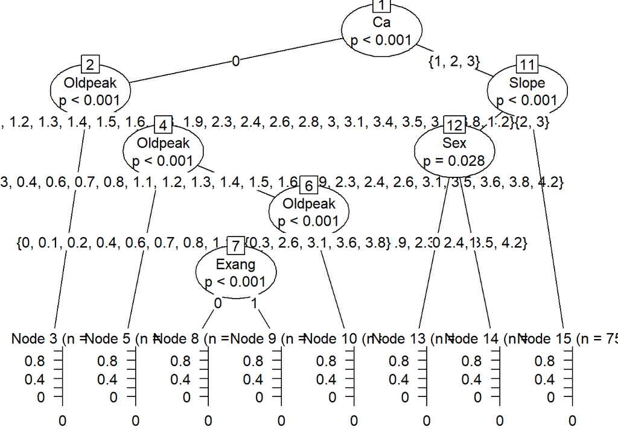

```r
## menggambarkan plot
plot(fit)
```

```r
table(predict(fit), trainData$Target)
```

```
##
##       0   1   2   3   4
##   0 141  19   2   9   0
##   1  11  14   7   4   4
##   2   5   5   7   0   0
##   3   7  17  20  22   9
##   4   0   0   0   0   0
```

```r
library(caret)
```

```r
# Membaca data uji
testData <- read.csv("D:\\KULIAH\\Dataset\\Pen data\\testData.csv")

# Mengonversi kolom menjadi faktor dengan tingkat yang sesuai
testData$Age <- factor(testData$Age, levels = levels(trainData$Age))
testData$Sex <- factor(testData$Sex, levels = levels(trainData$Sex))
testData$CP <- factor(testData$CP, levels = levels(trainData$CP))
testData$Trestbps <- factor(testData$Trestbps, levels = levels(trainData$Trestbps))
testData$Chol <- factor(testData$Chol, levels = levels(trainData$Chol))
testData$Fbs <- factor(testData$Fbs, levels = levels(trainData$Fbs))
testData$Restecg <- factor(testData$Restecg, levels = levels(trainData$Restecg))
testData$Thalach <- factor(testData$Thalach, levels = levels(trainData$Thalach))
testData$Exang <- factor(testData$Exang, levels = levels(trainData$Exang))
testData$Oldpeak <- factor(testData$Oldpeak, levels = levels(trainData$Oldpeak))
testData$Slope <- factor(testData$Slope, levels = levels(trainData$Slope))
testData$Ca <- factor(testData$Ca, levels = levels(trainData$Ca))
testData$Thal <- factor(testData$Thal, levels = levels(trainData$Thal))
testData$Target <- factor(testData$Target, levels = levels(trainData$Target))

str(testData)
```

```
## 'data.frame':    60 obs. of  14 variables:
##  $ Age     : Factor w/ 41 levels "29","34","35",..: 34 34 23 24 15 16 36 27 11 26 ...
##  $ Sex     : Factor w/ 2 levels "0","1": 2 2 2 2 1 2 1 2 2 2 ...
##  $ CP      : Factor w/ 4 levels "1","2","3","4": 4 4 3 3 3 2 1 4 3 3 ...
##  $ Trestbps: Factor w/ 50 levels "94","100","101",..: 41 15 23 35 23 23 29 13 23 35 ...
##  $ Chol    : Factor w/ 152 levels "126","131","141",..: 112 61 86 10 104 96 70 62 65 44 ...
##  $ Fbs     : Factor w/ 2 levels "0","1": 1 1 2 1 1 1 1 2 1 2 ...
##  $ Restecg : Factor w/ 3 levels "0","1","2": 3 3 3 1 1 1 1 1 1 1 ...
##  $ Thalach : Factor w/ 91 levels "71","88","90",..: 11 30 42 74 39 71 51 60 78 57 ...
##  $ Exang   : Factor w/ 2 levels "0","1": 2 2 2 1 1 1 1 2 2 1 ...
##  $ Oldpeak : Factor w/ 40 levels "0","0.1","0.2",..: 16 26 7 17 3 7 18 15 5 17 ...
##  $ Slope   : Factor w/ 3 levels "1","2","3": 2 2 2 1 1 1 1 1 1 1 ...
##  $ Ca      : Factor w/ 4 levels "0","1","2","3": 4 3 2 1 1 1 3 3 1 1 ...
##  $ Thal    : Factor w/ 4 levels "0","3","6","7": 2 4 3 2 2 2 2 4 2 2 ...
##  $ Target  : Factor w/ 5 levels "0","1","2","3",..: 3 2 3 1 1 1 1 3 1 1 ...
```

```r
# Perbaiki code program
prediksi <- predict(fit,newdata=testData,type="response")
prediksi
```

```
##  [1] 3 3 3 0 0 0 0 1 0 0 3 3 3 0 1 0 3 0 0 3 0 3 0 3 0 0 0 3 0 0 3 3 3 1 0 0 3 0
## [39] 0 0 3 0 0 0 3 1 0 0 0 3 0 0 3 0 0 0 0 3 0 3
## Levels: 0 1 2 3 4
```

```r
table_mat <- table(testData$Target,prediksi)
table_mat
```

```
##    prediksi
##      0  1  2  3  4
##   0 29  1  0  1  0
##   1  4  2  0  9  0
##   2  0  1  0  4  0
##   3  2  0  0  4  0
##   4  0  0  0  3  0
```

### Step: Membuat prediksi

Untuk membuat prediksi, menggunakan fungsi **predict()**.

```r
library(caret)
    confusionMatrix(table(testData$Target,prediksi))
```

```
## Confusion Matrix and Statistics
##
##    prediksi
##      0  1  2  3  4
##   0 29  1  0  1  0
##   1  4  2  0  9  0
##   2  0  1  0  4  0
##   3  2  0  0  4  0
##   4  0  0  0  3  0
##
## Overall Statistics
##
##                Accuracy : 0.5833
##                  95% CI : (0.4488, 0.7093)
##     No Information Rate : 0.5833
##     P-Value [Acc > NIR] : 0.5549
##
##                   Kappa : 0.3559
##
##  Mcnemar's Test P-Value : NA
##
## Statistics by Class:
##
##                      Class: 0 Class: 1 Class: 2 Class: 3 Class: 4
## Sensitivity            0.8286  0.50000       NA  0.19048       NA
## Specificity            0.9200  0.76786  0.91667  0.94872     0.95
## Pos Pred Value         0.9355  0.13333       NA  0.66667       NA
## Neg Pred Value         0.7931  0.95556       NA  0.68519       NA
## Prevalence             0.5833  0.06667  0.00000  0.35000     0.00
## Detection Rate         0.4833  0.03333  0.00000  0.06667     0.00
## Detection Prevalence   0.5167  0.25000  0.08333  0.10000     0.05
## Balanced Accuracy      0.8743  0.63393       NA  0.56960       NA
```

## E. Random Forest

### Step 1) Import Data

Data yang akan digunakan ialah data heart disease. Adapun datanya adalah sebagai berikut:

```r
trainData <- read.csv("D:\\KULIAH\\Dataset\\Pen data\\heart_disease_dataset.csv")
str(trainData)
```

```
## 'data.frame':    303 obs. of  14 variables:
##  $ Age     : int  63 67 67 37 41 56 62 57 63 53 ...
##  $ Sex     : int  1 1 1 1 0 1 0 0 1 1 ...
##  $ CP      : int  1 4 4 3 2 2 4 4 4 4 ...
##  $ Trestbps: int  145 160 120 130 130 120 140 120 130 140 ...
##  $ Chol    : int  233 286 229 250 204 236 268 354 254 203 ...
##  $ Fbs     : int  1 0 0 0 0 0 0 0 0 1 ...
##  $ Restecg : int  2 2 2 0 2 0 2 0 2 2 ...
##  $ Thalach : int  150 108 129 187 172 178 160 163 147 155 ...
##  $ Exang   : int  0 1 1 0 0 0 0 1 0 1 ...
##  $ Oldpeak : num  2.3 1.5 2.6 3.5 1.4 0.8 3.6 0.6 1.4 3.1 ...
##  $ Slope   : int  3 2 2 3 1 1 3 1 2 3 ...
##  $ Ca      : int  0 3 2 0 0 0 2 0 1 0 ...
##  $ Thal    : int  6 3 7 3 3 3 3 3 7 7 ...
##  $ Target  : int  0 2 1 0 0 0 3 0 2 1 ...
```

```r
trainData
```

```
##     Age Sex CP Trestbps Chol Fbs Restecg Thalach Exang Oldpeak Slope Ca Thal
## 1    63   1  1      145  233   1       2     150     0     2.3     3  0    6
## 2    67   1  4      160  286   0       2     108     1     1.5     2  3    3
## 3    67   1  4      120  229   0       2     129     1     2.6     2  2    7
## 4    37   1  3      130  250   0       0     187     0     3.5     3  0    3
## 5    41   0  2      130  204   0       2     172     0     1.4     1  0    3
## 6    56   1  2      120  236   0       0     178     0     0.8     1  0    3
## 7    62   0  4      140  268   0       2     160     0     3.6     3  2    3
## 8    57   0  4      120  354   0       0     163     1     0.6     1  0    3
## 9    63   1  4      130  254   0       2     147     0     1.4     2  1    7
## 10   53   1  4      140  203   1       2     155     1     3.1     3  0    7
## 11   57   1  4      140  192   0       0     148     0     0.4     2  0    6
## 12   56   0  2      140  294   0       2     153     0     1.3     2  0    3
## 13   56   1  3      130  256   1       2     142     1     0.6     2  1    6
## 14   44   1  2      120  263   0       0     173     0     0.0     1  0    7
```

[output cut: 593 more lines]

###Step 2) Mentraining model Salah satu cara untuk melakukan evaluasi terhadap sebuah model adalah men-train model pada sekumpulan dataset yang lebih kecil dan mengevaluasinya menggunakan data testing yang lebih kecil. Teknik evaluasi ini dikenal dengan feature F-fold-cross-validation. R memiliki sebuah fungsi yang membagi sejumlah data secara random dengan ukuran yang sama. Sebagai contoh, jika k=9 maka model dievaluasi menggunakan 9 folder dan ditesting pada sisa dataset nya. Proses ini diulang sampai seluruh subset selesai dievaluasi. Teknik ini banyak digunakan untuk melakukan pemilihan model, terutama jika model memerlukan parameter yang perlu disetting

Setelah mengetahui cara untuk melakukan evaluasi, maka selanjutnya adalah memilih parameter yang dapat mengeneralisasi data yang paling baik.

Random Forest memilih secara acak fitur/varibel dan membangun banyak Decision Tree. Model menghitung rata-rata semua prediksi dari Decision tree.

Random Forest memiliki beberapa parameter yang dapt diubah untuk meningkatan generalisasi dari prediksi.

Fungsi RandomForest() digunakan untuk melakukan training model

```r
library(randomForest)
library(caret)
```

```r
library(e1071)
trControl <- trainControl(method="cv", number=5,search="grid")
```

```r
trainData$Target <- factor(trainData$Target)
str(trainData)
```

```
## 'data.frame':    303 obs. of  14 variables:
##  $ Age     : int  63 67 67 37 41 56 62 57 63 53 ...
##  $ Sex     : int  1 1 1 1 0 1 0 0 1 1 ...
##  $ CP      : int  1 4 4 3 2 2 4 4 4 4 ...
##  $ Trestbps: int  145 160 120 130 130 120 140 120 130 140 ...
##  $ Chol    : int  233 286 229 250 204 236 268 354 254 203 ...
##  $ Fbs     : int  1 0 0 0 0 0 0 0 0 1 ...
##  $ Restecg : int  2 2 2 0 2 0 2 0 2 2 ...
##  $ Thalach : int  150 108 129 187 172 178 160 163 147 155 ...
##  $ Exang   : int  0 1 1 0 0 0 0 1 0 1 ...
##  $ Oldpeak : num  2.3 1.5 2.6 3.5 1.4 0.8 3.6 0.6 1.4 3.1 ...
##  $ Slope   : int  3 2 2 3 1 1 3 1 2 3 ...
##  $ Ca      : int  0 3 2 0 0 0 2 0 1 0 ...
##  $ Thal    : int  6 3 7 3 3 3 3 3 7 7 ...
##  $ Target  : Factor w/ 5 levels "0","1","2","3",..: 1 3 2 1 1 1 4 1 3 2 ...
```

```r
set.seed(1234)

# Run the model
rf_default <- train(Target~.,
    data = trainData,
    method = "rf",
    metric = "Accuracy",
    trControl = trControl)
```

```r
# Print the results
print(rf_default)
```

```
## Random Forest
##
## 303 samples
##  13 predictor
##   5 classes: '0', '1', '2', '3', '4'
##
## No pre-processing
## Resampling: Cross-Validated (5 fold)
## Summary of sample sizes: 242, 244, 243, 241, 242
## Resampling results across tuning parameters:
##
##   mtry  Accuracy   Kappa
##    2    0.5873377  0.2849750
##    7    0.5544963  0.2548121
##   13    0.5378770  0.2406330
##
## Accuracy was used to select the optimal model using the largest value.
## The final value used for the model was mtry = 2.
```

Analisis hasil : Algoritma menggunakan 500 tree dan ditesting menggunakan nilai mtry yang berbeda-beda yaitu 2, 7, 13. Final model yang digunakan adalah mtry=2 dengan akurasi 0.58

Membangun model random forest dapat dilakukan dengan memanggil fungsi randomforest

```r
rf_default2 <- randomForest(trainData)
print(rf_default2)
```

```
##
## Call:
##  randomForest(x = trainData)
##                Type of random forest: unsupervised
##                      Number of trees: 500
## No. of variables tried at each split: 3
```

```r
summary(rf_default2)
```

```
##                 Length Class  Mode
## call                2  -none- call
## type                1  -none- character
## predicted           0  -none- NULL
## err.rate            0  -none- NULL
## confusion           0  -none- NULL
## votes             606  matrix numeric
## oob.times         303  -none- numeric
## classes             2  -none- character
## importance         14  -none- numeric
## importanceSD        0  -none- NULL
## localImportance     0  -none- NULL
## proximity       91809  -none- numeric
## ntree               1  -none- numeric
## mtry                1  -none- numeric
## forest              0  -none- NULL
## y                   0  -none- NULL
## test                0  -none- NULL
## inbag               0  -none- NULL
```

```r
rf_default2
```

```
##
## Call:
##  randomForest(x = trainData)
##                Type of random forest: unsupervised
##                      Number of trees: 500
## No. of variables tried at each split: 3
```

```r
importance(rf_default2)
```

```
##          MeanDecreaseGini
## Age             36.161695
## Sex              8.369488
## CP              17.783289
## Trestbps        31.394048
## Chol            36.801422
## Fbs              4.816483
## Restecg          7.644021
## Thalach         43.215524
## Exang            9.923984
## Oldpeak         33.207923
## Slope           14.467691
## Ca              14.994294
## Thal            14.096310
## Target          24.822884
```

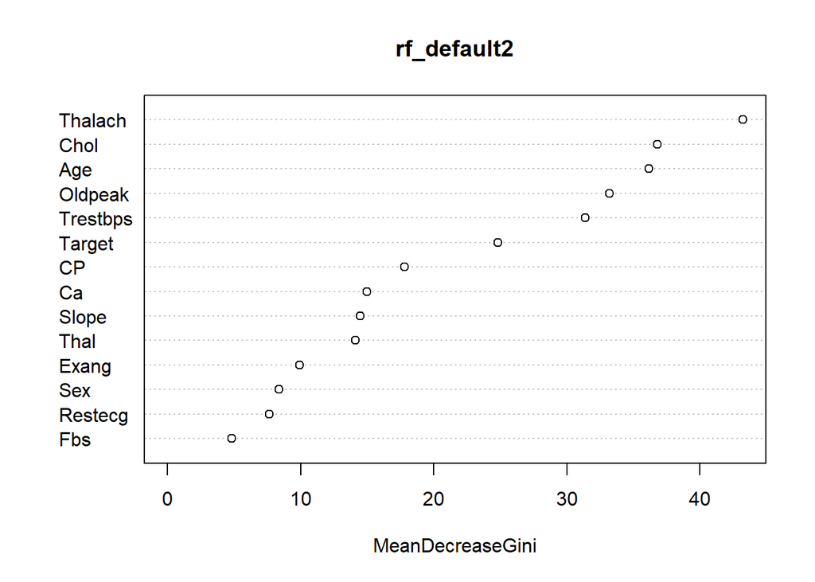

```r
varImpPlot(rf_default2)
```

###Step 3): Membuat fungsi akurasi Untuk dapat meningkatkan akurasi dari model yang menggunakan nilai default dapat dengan berbagai cara yaitu:

Find the best number of mtry Find the best number of maxnodes Find the best number of ntrees Evaluate the model on the test dataset

```r
set.seed(1234)
tuneGrid <- expand.grid(.mtry = c(1:10))
rf_mtry <- train(Target~.,
    data = trainData,
    method = "rf",
    metric = "Accuracy",
    tuneGrid = tuneGrid,
    trControl = trControl,
    importance = TRUE,
    nodesize = 14,
    ntree = 300)
```

```r
print(rf_mtry)
```

```
## Random Forest
##
## 303 samples
##  13 predictor
##   5 classes: '0', '1', '2', '3', '4'
##
## No pre-processing
## Resampling: Cross-Validated (5 fold)
## Summary of sample sizes: 242, 244, 243, 241, 242
## Resampling results across tuning parameters:
##
##   mtry  Accuracy   Kappa
##    1    0.5611047  0.1162757
##    2    0.5972338  0.2700795
##    3    0.5873942  0.2686325
##    4    0.5972885  0.2953540
##    5    0.5672794  0.2565822
##    6    0.5773923  0.2665454
##    7    0.5771737  0.2723390
##    8    0.5738950  0.2757324
##    9    0.5902902  0.2919889
##   10    0.5672265  0.2582173
##
## Accuracy was used to select the optimal model using the largest value.
## The final value used for the model was mtry = 4.
```

```r
## menyimpan nilai mtry terbaik
best_mtry <- rf_mtry$bestTune$mtry
best_mtry
```

```
## [1] 4
```

```r
##Menyimpan dan menggunakan
max(rf_mtry$results$Accuracy)
```

```
## [1] 0.5972885
```

Search the best maxnodes Untuk mengevaluasi model, maka perlu membuat loop untuk membuat evaluasi terhadap beberapa nilai dari maxnodes. Berikut langkahnya :

1. Create a list
2. Create a variable with the best value of the parameter mtry; WAJIB
3. Create the loop
4. Store the current value of maxnode
5. Summarize the results

```r
store_maxnode <- list()
tuneGrid <- expand.grid(.mtry = best_mtry)
for (maxnodes in c(2: 5)) {
    set.seed(1234)
    rf_maxnode <- train(Target~.,
        data = trainData,
        method = "rf",
        metric = "Accuracy",
        tuneGrid = tuneGrid,
        trControl = trControl,
        importance = TRUE,
        nodesize = 14,
        maxnodes = maxnodes,
        ntree = 300)
    current_iteration <- toString(maxnodes)
    store_maxnode[[current_iteration]] <- rf_maxnode
}
```

```r
results_mtry <- resamples(store_maxnode)
summary(results_mtry)
```

```
##
## Call:
## summary.resamples(object = results_mtry)
##
## Models: 2, 3, 4, 5
## Number of resamples: 5
##
## Accuracy
##        Min.   1st Qu.    Median      Mean   3rd Qu.      Max. NA's
## 2 0.5322581 0.5409836 0.5409836 0.5447095 0.5500000 0.5593220    0
## 3 0.5409836 0.5500000 0.5573770 0.5544398 0.5593220 0.5645161    0
## 4 0.5322581 0.5573770 0.5573770 0.5546002 0.5593220 0.5666667    0
## 5 0.5322581 0.5593220 0.5737705 0.5644909 0.5737705 0.5833333    0
##
## Kappa
##        Min.   1st Qu.     Median       Mean    3rd Qu.      Max. NA's
## 2 0.0000000 0.0000000 0.00000000 0.01473430 0.00000000 0.0736715    0
## 3 0.0000000 0.0000000 0.07158963 0.05402104 0.09658422 0.1019313    0
## 4 0.0910596 0.1010000 0.14660832 0.13245589 0.15190525 0.1717063    0
## 5 0.1001001 0.1247241 0.13916947 0.14980757 0.19093851 0.1941057    0
```

Penjelasan kode program:

store_maxnode <- list(): Hasil dari model disimpan dalam list expand.grid(.mtry=best_mtry): menggunakan nilai terbaik dari mtry for (maxnodes in c(2:5)) { … }: mengevaluasi model dengan nilai maxnote dari 2 sampai dengan 5 maxnodes=maxnodes: Untuk setiap iterasi, maxnodes adalah sama dengan maxnodes saat ini. yaitu 2, 3, 4 … key <- toString(maxnodes): simpan sebagai string variable dari nilai maxnode store_maxnode[[key]] <- rf_maxnode: simpan hasil model dalam list/ resamples(store_maxnode): Arrange the results of the model summary(results_mtry): tampilkan seluruh kombinasi

Nilai maxnode terakhir yang memiliki nilai akurasi tertinggi. Kemudian dicoba dengan nilai tertinggi apakah diperoleh score tertinggi.

```r
store_maxnode <- list()
tuneGrid <- expand.grid(.mtry = best_mtry)
for (maxnodes in c(5: 10)) {
    set.seed(1234)
    rf_maxnode <- train(Target~.,
        data = trainData,
        method = "rf",
        metric = "Accuracy",
        tuneGrid = tuneGrid,
        trControl = trControl,
        importance = TRUE,
        nodesize = 14,
        maxnodes = maxnodes,
        ntree = 300)
    key <- toString(maxnodes)
    store_maxnode[[key]] <- rf_maxnode
}
```

```r
results_mtry <- resamples(store_maxnode)
summary(results_mtry)
```

```
##
## Call:
## summary.resamples(object = results_mtry)
##
## Models: 5, 6, 7, 8, 9, 10
## Number of resamples: 5
##
## Accuracy
##         Min.   1st Qu.    Median      Mean   3rd Qu.      Max. NA's
## 5  0.5322581 0.5593220 0.5737705 0.5644909 0.5737705 0.5833333    0
## 6  0.5322581 0.5593220 0.5666667 0.5644362 0.5737705 0.5901639    0
## 7  0.5333333 0.5593220 0.5901639 0.5739515 0.5901639 0.5967742    0
## 8  0.5593220 0.5666667 0.5737705 0.5773395 0.5901639 0.5967742    0
## 9  0.5573770 0.5593220 0.5833333 0.5773941 0.5901639 0.5967742    0
## 10 0.5423729 0.5500000 0.5645161 0.5608860 0.5737705 0.5737705    0
##
## Kappa
##         Min.   1st Qu.    Median      Mean   3rd Qu.      Max. NA's
## 5  0.1001001 0.1247241 0.1391695 0.1498076 0.1909385 0.1941057    0
## 6  0.1305609 0.1702128 0.1831736 0.1840201 0.1941057 0.2420477    0
## 7  0.1286307 0.1814301 0.2420477 0.2182990 0.2487685 0.2906178    0
## 8  0.1972789 0.2089249 0.2285992 0.2335586 0.2420477 0.2909424    0
## 9  0.2060041 0.2209082 0.2276004 0.2372406 0.2420477 0.2896425    0
## 10 0.1771694 0.1932271 0.2117296 0.2145207 0.2338164 0.2566607    0
```

##Find the best of ntress setelah mendapatkan best mtry dan maxnode, selanjutkan dapat melakukan tuning pada jumlah trees. Cara yang dilakukan sama dengan maxnode.

```r
store_maxtrees <- list()
for (ntree in c(250, 300, 350, 400, 450, 500, 550, 600, 800, 1000, 2000)) {
    set.seed(5678)
    rf_maxtrees <- train(Target~.,
        data = trainData,
        method = "rf",
        metric = "Accuracy",
        tuneGrid = tuneGrid,
        trControl = trControl,
        importance = TRUE,
        nodesize = 14,
        maxnodes = 4,
        ntree = ntree)
    key <- toString(ntree)
    store_maxtrees[[key]] <- rf_maxtrees
}
```

```r
results_tree <- resamples(store_maxtrees)
summary(results_tree)
```

```
##
## Call:
## summary.resamples(object = results_tree)
##
## Models: 250, 300, 350, 400, 450, 500, 550, 600, 800, 1000, 2000
## Number of resamples: 5
##
## Accuracy
##           Min.   1st Qu.    Median      Mean   3rd Qu.      Max. NA's
## 250  0.5322581 0.5666667 0.5737705 0.5678724 0.5833333 0.5833333    0
## 300  0.5161290 0.5666667 0.5666667 0.5613132 0.5737705 0.5833333    0
## 350  0.5161290 0.5666667 0.5666667 0.5613132 0.5737705 0.5833333    0
## 400  0.5322581 0.5500000 0.5666667 0.5612057 0.5737705 0.5833333    0
## 450  0.5161290 0.5500000 0.5666667 0.5579799 0.5737705 0.5833333    0
## 500  0.5161290 0.5666667 0.5666667 0.5613132 0.5737705 0.5833333    0
## 550  0.5322581 0.5500000 0.5666667 0.5612057 0.5737705 0.5833333    0
## 600  0.5161290 0.5500000 0.5666667 0.5579799 0.5737705 0.5833333    0
## 800  0.5322581 0.5573770 0.5666667 0.5612604 0.5666667 0.5833333    0
## 1000 0.5161290 0.5573770 0.5666667 0.5547012 0.5666667 0.5666667    0
## 2000 0.5322581 0.5573770 0.5666667 0.5612604 0.5666667 0.5833333    0
##
## Kappa
##            Min.    1st Qu.    Median      Mean   3rd Qu.      Max. NA's
## 250  0.11428571 0.12952799 0.1314031 0.1513551 0.1794311 0.2021277    0
## 300  0.08419498 0.12063134 0.1295280 0.1386329 0.1793793 0.1794311    0
## 350  0.07231920 0.12952799 0.1314031 0.1365788 0.1702128 0.1794311    0
## 400  0.11428571 0.12952799 0.1314031 0.1385892 0.1382979 0.1794311    0
## 450  0.08419498 0.12063134 0.1295280 0.1326783 0.1496063 0.1794311    0
## 500  0.08419498 0.12063134 0.1295280 0.1389775 0.1794311 0.1811024    0
## 550  0.09191919 0.12063134 0.1295280 0.1342232 0.1496063 0.1794311    0
## 600  0.07278166 0.12063134 0.1295280 0.1303957 0.1496063 0.1794311    0
## 800  0.09191919 0.09405941 0.1206313 0.1312508 0.1702128 0.1794311    0
## 1000 0.07278166 0.09405941 0.1206313 0.1208587 0.1466083 0.1702128    0
## 2000 0.09191919 0.09405941 0.1206313 0.1334287 0.1794311 0.1811024    0
```

```r
fit_rf <- train(Target~.,
    trainData,
    method = "rf",
    metric = "Accuracy",
    tuneGrid = tuneGrid,
    trControl = trControl,
    importance = TRUE,
    nodesize = 14,
    ntree = 300,
    maxnodes = 14)
```

```r
print(fit_rf)
```

```
## Random Forest
##
## 303 samples
##  13 predictor
##   5 classes: '0', '1', '2', '3', '4'
##
## No pre-processing
## Resampling: Cross-Validated (5 fold)
## Summary of sample sizes: 242, 242, 243, 241, 244
## Resampling results:
##
##   Accuracy   Kappa
##   0.5744982  0.2445618
##
## Tuning parameter 'mtry' was held constant at a value of 4
```

###Step 4) : Visualisasi Model

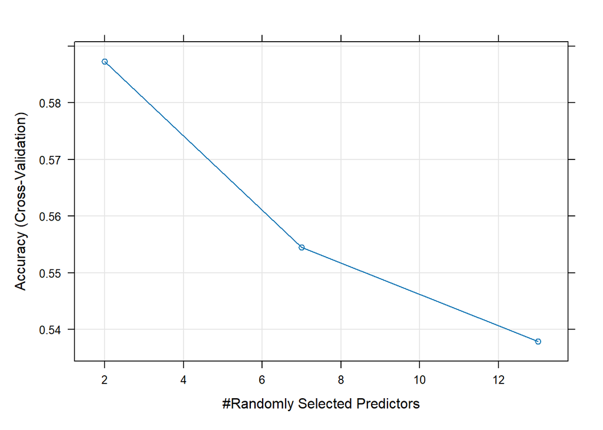

```r
plot(rf_default)
```

```r
varImp(rf_default)
```

```
## rf variable importance
##
##          Overall
## Thalach  100.000
## Oldpeak   86.138
## Chol      78.983
## Age       75.722
## Ca        70.281
## Trestbps  67.747
## Thal      57.489
## CP        54.658
## Exang     24.485
## Slope     23.584
## Restecg    9.927
## Sex        8.572
## Fbs        0.000
```

###Step 5) Evaluasi model Evaluasi model dengan menggunakan data testing. Menggunakan library caret function predict

```r
library(caret)
testData <- read.csv("D:\\KULIAH\\Dataset\\Pen data\\testData.csv")
str(testData)
```

```
## 'data.frame':    60 obs. of  14 variables:
##  $ Age     : int  67 67 56 57 48 49 69 60 44 59 ...
##  $ Sex     : int  1 1 1 1 0 1 0 1 1 1 ...
##  $ CP      : int  4 4 3 3 3 2 1 4 3 3 ...
##  $ Trestbps: int  160 120 130 150 130 130 140 117 130 150 ...
##  $ Chol    : int  286 229 256 168 275 266 239 230 233 212 ...
##  $ Fbs     : int  0 0 1 0 0 0 0 1 0 1 ...
##  $ Restecg : int  2 2 2 0 0 0 0 0 0 0 ...
##  $ Thalach : int  108 129 142 174 139 171 151 160 179 157 ...
##  $ Exang   : int  1 1 1 0 0 0 0 1 1 0 ...
##  $ Oldpeak : num  1.5 2.6 0.6 1.6 0.2 0.6 1.8 1.4 0.4 1.6 ...
##  $ Slope   : int  2 2 2 1 1 1 1 1 1 1 ...
##  $ Ca      : int  3 2 1 0 0 0 2 2 0 0 ...
##  $ Thal    : int  3 7 6 3 3 3 3 7 3 3 ...
##  $ Target  : int  2 1 2 0 0 0 0 2 0 0 ...
```

```r
prediksi <- predict(rf_default,testData)
prediksi
```

```
##  [1] 2 1 2 0 0 0 0 2 0 0 4 1 2 0 1 3 3 0 0 1 0 4 0 1 0 0 0 1 0 0 4 1 1 0 1 0 3 3
## [39] 1 0 3 0 0 0 1 1 0 0 0 1 0 1 0 0 0 0 0 3 1 2
## Levels: 0 1 2 3 4
```

```r
confusionMatrix(table(testData$Target,prediksi))
```

```
## Confusion Matrix and Statistics
##
##    prediksi
##      0  1  2  3  4
##   0 31  0  0  0  0
##   1  0 15  0  0  0
##   2  0  0  5  0  0
##   3  0  0  0  6  0
##   4  0  0  0  0  3
##
## Overall Statistics
##
##                Accuracy : 1
##                  95% CI : (0.9404, 1)
##     No Information Rate : 0.5167
##     P-Value [Acc > NIR] : < 2.2e-16
##
##                   Kappa : 1
##
##  Mcnemar's Test P-Value : NA
##
## Statistics by Class:
##
##                      Class: 0 Class: 1 Class: 2 Class: 3 Class: 4
## Sensitivity            1.0000     1.00  1.00000      1.0     1.00
## Specificity            1.0000     1.00  1.00000      1.0     1.00
## Pos Pred Value         1.0000     1.00  1.00000      1.0     1.00
## Neg Pred Value         1.0000     1.00  1.00000      1.0     1.00
## Prevalence             0.5167     0.25  0.08333      0.1     0.05
## Detection Rate         0.5167     0.25  0.08333      0.1     0.05
## Detection Prevalence   0.5167     0.25  0.08333      0.1     0.05
## Balanced Accuracy      1.0000     1.00  1.00000      1.0     1.00
```

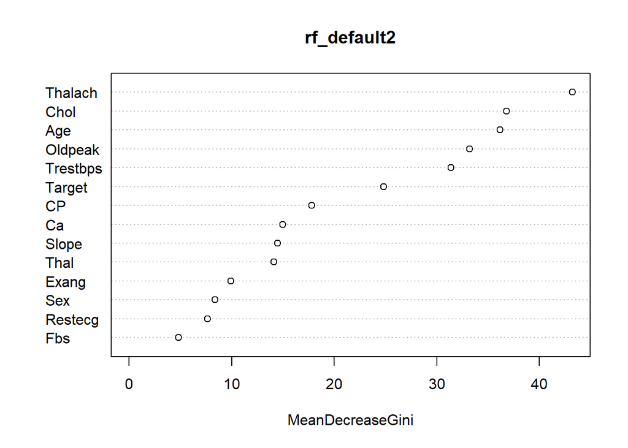

```r
varImpPlot(rf_default2)
```

## F. Bagging CART: Bentuk ensemble

### Step) Membuat training data dan merubah kolom target menjadi factor

```r
library(ipred)
```

```r
trainData <- read.csv("D:\\KULIAH\\Dataset\\Pen data\\heart_disease_dataset.csv")
trainData$Target <- factor(trainData$Target)
str(trainData)
```

```
## 'data.frame':    303 obs. of  14 variables:
##  $ Age     : int  63 67 67 37 41 56 62 57 63 53 ...
##  $ Sex     : int  1 1 1 1 0 1 0 0 1 1 ...
##  $ CP      : int  1 4 4 3 2 2 4 4 4 4 ...
##  $ Trestbps: int  145 160 120 130 130 120 140 120 130 140 ...
##  $ Chol    : int  233 286 229 250 204 236 268 354 254 203 ...
##  $ Fbs     : int  1 0 0 0 0 0 0 0 0 1 ...
##  $ Restecg : int  2 2 2 0 2 0 2 0 2 2 ...
##  $ Thalach : int  150 108 129 187 172 178 160 163 147 155 ...
##  $ Exang   : int  0 1 1 0 0 0 0 1 0 1 ...
##  $ Oldpeak : num  2.3 1.5 2.6 3.5 1.4 0.8 3.6 0.6 1.4 3.1 ...
##  $ Slope   : int  3 2 2 3 1 1 3 1 2 3 ...
##  $ Ca      : int  0 3 2 0 0 0 2 0 1 0 ...
##  $ Thal    : int  6 3 7 3 3 3 3 3 7 7 ...
##  $ Target  : Factor w/ 5 levels "0","1","2","3",..: 1 3 2 1 1 1 4 1 3 2 ...
```

```r
trainData
```

```
##     Age Sex CP Trestbps Chol Fbs Restecg Thalach Exang Oldpeak Slope Ca Thal
## 1    63   1  1      145  233   1       2     150     0     2.3     3  0    6
## 2    67   1  4      160  286   0       2     108     1     1.5     2  3    3
## 3    67   1  4      120  229   0       2     129     1     2.6     2  2    7
## 4    37   1  3      130  250   0       0     187     0     3.5     3  0    3
## 5    41   0  2      130  204   0       2     172     0     1.4     1  0    3
## 6    56   1  2      120  236   0       0     178     0     0.8     1  0    3
## 7    62   0  4      140  268   0       2     160     0     3.6     3  2    3
## 8    57   0  4      120  354   0       0     163     1     0.6     1  0    3
## 9    63   1  4      130  254   0       2     147     0     1.4     2  1    7
## 10   53   1  4      140  203   1       2     155     1     3.1     3  0    7
## 11   57   1  4      140  192   0       0     148     0     0.4     2  0    6
## 12   56   0  2      140  294   0       2     153     0     1.3     2  0    3
## 13   56   1  3      130  256   1       2     142     1     0.6     2  1    6
## 14   44   1  2      120  263   0       0     173     0     0.0     1  0    7
```

[output cut: 593 more lines]

### Step) : Membangun model

untuk membangun model, gunakan fungsi **bagging** dari library **ipred**.

```r
myFormula <- Target~Age+Sex+CP+Trestbps+Chol+Fbs+Restecg+Thalach+Exang+Oldpeak+Slope+Ca+Thal

fit <-bagging(myFormula,data=trainData,ntree=10)
fit
```

```
##
## Bagging classification trees with 25 bootstrap replications
##
## Call: bagging.data.frame(formula = myFormula, data = trainData, ntree = 10)
```

### Step) : Membuat prediksi

Untuk membuat prediksi, menggunakan fungsi **predict()**.

```r
testData <- read.csv("D:\\KULIAH\\Dataset\\Pen data\\testData.csv")

str(testData)
```

```
## 'data.frame':    60 obs. of  14 variables:
##  $ Age     : int  67 67 56 57 48 49 69 60 44 59 ...
##  $ Sex     : int  1 1 1 1 0 1 0 1 1 1 ...
##  $ CP      : int  4 4 3 3 3 2 1 4 3 3 ...
##  $ Trestbps: int  160 120 130 150 130 130 140 117 130 150 ...
##  $ Chol    : int  286 229 256 168 275 266 239 230 233 212 ...
##  $ Fbs     : int  0 0 1 0 0 0 0 1 0 1 ...
##  $ Restecg : int  2 2 2 0 0 0 0 0 0 0 ...
##  $ Thalach : int  108 129 142 174 139 171 151 160 179 157 ...
##  $ Exang   : int  1 1 1 0 0 0 0 1 1 0 ...
##  $ Oldpeak : num  1.5 2.6 0.6 1.6 0.2 0.6 1.8 1.4 0.4 1.6 ...
##  $ Slope   : int  2 2 2 1 1 1 1 1 1 1 ...
##  $ Ca      : int  3 2 1 0 0 0 2 2 0 0 ...
##  $ Thal    : int  3 7 6 3 3 3 3 7 3 3 ...
##  $ Target  : int  2 1 2 0 0 0 0 2 0 0 ...
```

```r
testData
```

```
##    Age Sex CP Trestbps Chol Fbs Restecg Thalach Exang Oldpeak Slope Ca Thal
## 1   67   1  4      160  286   0       2     108     1     1.5     2  3    3
## 2   67   1  4      120  229   0       2     129     1     2.6     2  2    7
## 3   56   1  3      130  256   1       2     142     1     0.6     2  1    6
## 4   57   1  3      150  168   0       0     174     0     1.6     1  0    3
## 5   48   0  3      130  275   0       0     139     0     0.2     1  0    3
## 6   49   1  2      130  266   0       0     171     0     0.6     1  0    3
## 7   69   0  1      140  239   0       0     151     0     1.8     1  2    3
## 8   60   1  4      117  230   1       0     160     1     1.4     1  2    7
## 9   44   1  3      130  233   0       0     179     1     0.4     1  0    3
## 10  59   1  3      150  212   1       0     157     0     1.6     1  0    3
## 11  58   1  3      112  230   0       2     165     0     2.5     2  1    7
## 12  54   1  4      124  266   0       2     109     1     2.2     2  1    7
## 13  60   1  4      145  282   0       2     142     1     2.8     2  2    7
## 14  65   0  3      155  269   0       0     148     0     0.8     1  0    3
```

[output cut: 107 more lines]

```r
#membuat prediksi (Bagging)
library(caret)
```

```r
fit_prediksi <- predict(fit,newdata=testData)
```

```r
confusionMatrix(table(fit_prediksi,testData$Target))
```

```
## Confusion Matrix and Statistics
##
##
## fit_prediksi  0  1  2  3  4
##            0 31  0  0  0  0
##            1  0 15  0  0  0
##            2  0  0  5  0  0
##            3  0  0  0  6  0
##            4  0  0  0  0  3
##
## Overall Statistics
##
##                Accuracy : 1
##                  95% CI : (0.9404, 1)
##     No Information Rate : 0.5167
##     P-Value [Acc > NIR] : < 2.2e-16
##
##                   Kappa : 1
##
##  Mcnemar's Test P-Value : NA
##
## Statistics by Class:
##
##                      Class: 0 Class: 1 Class: 2 Class: 3 Class: 4
## Sensitivity            1.0000     1.00  1.00000      1.0     1.00
## Specificity            1.0000     1.00  1.00000      1.0     1.00
## Pos Pred Value         1.0000     1.00  1.00000      1.0     1.00
## Neg Pred Value         1.0000     1.00  1.00000      1.0     1.00
## Prevalence             0.5167     0.25  0.08333      0.1     0.05
## Detection Rate         0.5167     0.25  0.08333      0.1     0.05
## Detection Prevalence   0.5167     0.25  0.08333      0.1     0.05
## Balanced Accuracy      1.0000     1.00  1.00000      1.0     1.00
```

## G. Boosted C5.0

### Step) Membuat training data dan merubah kolom target menjadi factor

```r
library(C50)
trainData <- read.csv("D:\\KULIAH\\Dataset\\Pen data\\heart_disease_dataset.csv")
trainData$Target <- as.factor(trainData$Target)

str(trainData)
```

```
## 'data.frame':    303 obs. of  14 variables:
##  $ Age     : int  63 67 67 37 41 56 62 57 63 53 ...
##  $ Sex     : int  1 1 1 1 0 1 0 0 1 1 ...
##  $ CP      : int  1 4 4 3 2 2 4 4 4 4 ...
##  $ Trestbps: int  145 160 120 130 130 120 140 120 130 140 ...
##  $ Chol    : int  233 286 229 250 204 236 268 354 254 203 ...
##  $ Fbs     : int  1 0 0 0 0 0 0 0 0 1 ...
##  $ Restecg : int  2 2 2 0 2 0 2 0 2 2 ...
##  $ Thalach : int  150 108 129 187 172 178 160 163 147 155 ...
##  $ Exang   : int  0 1 1 0 0 0 0 1 0 1 ...
##  $ Oldpeak : num  2.3 1.5 2.6 3.5 1.4 0.8 3.6 0.6 1.4 3.1 ...
##  $ Slope   : int  3 2 2 3 1 1 3 1 2 3 ...
##  $ Ca      : int  0 3 2 0 0 0 2 0 1 0 ...
##  $ Thal    : int  6 3 7 3 3 3 3 3 7 7 ...
##  $ Target  : Factor w/ 5 levels "0","1","2","3",..: 1 3 2 1 1 1 4 1 3 2 ...
```

```r
trainData
```

```
##     Age Sex CP Trestbps Chol Fbs Restecg Thalach Exang Oldpeak Slope Ca Thal
## 1    63   1  1      145  233   1       2     150     0     2.3     3  0    6
## 2    67   1  4      160  286   0       2     108     1     1.5     2  3    3
## 3    67   1  4      120  229   0       2     129     1     2.6     2  2    7
## 4    37   1  3      130  250   0       0     187     0     3.5     3  0    3
## 5    41   0  2      130  204   0       2     172     0     1.4     1  0    3
## 6    56   1  2      120  236   0       0     178     0     0.8     1  0    3
## 7    62   0  4      140  268   0       2     160     0     3.6     3  2    3
## 8    57   0  4      120  354   0       0     163     1     0.6     1  0    3
## 9    63   1  4      130  254   0       2     147     0     1.4     2  1    7
## 10   53   1  4      140  203   1       2     155     1     3.1     3  0    7
## 11   57   1  4      140  192   0       0     148     0     0.4     2  0    6
## 12   56   0  2      140  294   0       2     153     0     1.3     2  0    3
## 13   56   1  3      130  256   1       2     142     1     0.6     2  1    6
## 14   44   1  2      120  263   0       0     173     0     0.0     1  0    7
```

[output cut: 593 more lines]

### Step) : Membangun model

untuk membangun model, gunakan fungsi **C5.0** dari library **C50**.

```r
##Membangun Model
myFormula <- Target~Age+Sex+CP+Trestbps+Chol+Fbs+Restecg+Thalach+Exang+ Oldpeak+Slope+Ca+Thal

fit <-C5.0(myFormula,data=trainData,trial=10)
print(fit)
```

```
##
## Call:
## C5.0.formula(formula = myFormula, data = trainData, trial = 10)
##
## Classification Tree
## Number of samples: 303
## Number of predictors: 13
##
## Number of boosting iterations: 10
## Average tree size: 41.3
##
## Non-standard options: attempt to group attributes
```

```r
summary(fit)
```

```
##
## Call:
## C5.0.formula(formula = myFormula, data = trainData, trial = 10)
##
##
## C5.0 [Release 2.07 GPL Edition]      Mon Dec  4 10:24:29 2023
## -------------------------------
##
## Class specified by attribute `outcome'
##
## Read 303 cases (14 attributes) from undefined.data
##
## -----  Trial 0:  -----
##
## Decision tree:
##
## Thal <= 3:
## :...Ca <= 0: 0 (119/14)
## :   Ca > 0:
## :   :...CP <= 3:
## :       :...Sex <= 0: 0 (16/2)
## :       :   Sex > 0:
## :       :   :...Age <= 55: 0 (8/1)
## :       :       Age > 55:
## :       :       :...Thalach <= 153: 0 (2/1)
## :       :           Thalach > 153: 1 (3)
## :       CP > 3:
## :       :...Sex <= 0:
## :           :...Trestbps <= 134: 0 (4/1)
## :           :   Trestbps > 134: 2 (2/1)
## :           Sex > 0:
## :           :...Exang <= 0: 1 (4/1)
## :               Exang > 0:
## :               :...Slope <= 1: 2 (2/1)
## :                   Slope > 1:
## :                   :...Trestbps > 130: 2 (2/1)
## :                       Trestbps <= 130:
## :                       :...Ca > 1: 3 (2)
## :                           Ca <= 1:
## :                           :...Chol <= 247: 3 (2)
```

[output cut: 860 more lines]

```
##  100.00% Oldpeak
##  100.00% Ca
##  100.00% Thal
##   99.67% Thalach
##   97.36% Age
##   97.03% Fbs
##   96.37% Slope
##   95.38% Exang
##   91.09% Chol
##   86.14% Sex
##   75.58% Restecg
##   48.51% Trestbps
##
##
## Time: 0.0 secs
```

### Step) : Membuat prediksi

Untuk membuat prediksi, menggunakan fungsi **predict()**.

```r
testData <- read.csv("D:\\KULIAH\\Dataset\\Pen data\\testData.csv")
testData$Target <- factor(testData$Target)

str(testData)
```

```
## 'data.frame':    60 obs. of  14 variables:
##  $ Age     : int  67 67 56 57 48 49 69 60 44 59 ...
##  $ Sex     : int  1 1 1 1 0 1 0 1 1 1 ...
##  $ CP      : int  4 4 3 3 3 2 1 4 3 3 ...
##  $ Trestbps: int  160 120 130 150 130 130 140 117 130 150 ...
##  $ Chol    : int  286 229 256 168 275 266 239 230 233 212 ...
##  $ Fbs     : int  0 0 1 0 0 0 0 1 0 1 ...
##  $ Restecg : int  2 2 2 0 0 0 0 0 0 0 ...
##  $ Thalach : int  108 129 142 174 139 171 151 160 179 157 ...
##  $ Exang   : int  1 1 1 0 0 0 0 1 1 0 ...
##  $ Oldpeak : num  1.5 2.6 0.6 1.6 0.2 0.6 1.8 1.4 0.4 1.6 ...
##  $ Slope   : int  2 2 2 1 1 1 1 1 1 1 ...
##  $ Ca      : int  3 2 1 0 0 0 2 2 0 0 ...
##  $ Thal    : int  3 7 6 3 3 3 3 7 3 3 ...
##  $ Target  : Factor w/ 5 levels "0","1","2","3",..: 3 2 3 1 1 1 1 3 1 1 ...
```

```r
testData
```

```
##    Age Sex CP Trestbps Chol Fbs Restecg Thalach Exang Oldpeak Slope Ca Thal
## 1   67   1  4      160  286   0       2     108     1     1.5     2  3    3
## 2   67   1  4      120  229   0       2     129     1     2.6     2  2    7
## 3   56   1  3      130  256   1       2     142     1     0.6     2  1    6
## 4   57   1  3      150  168   0       0     174     0     1.6     1  0    3
## 5   48   0  3      130  275   0       0     139     0     0.2     1  0    3
## 6   49   1  2      130  266   0       0     171     0     0.6     1  0    3
## 7   69   0  1      140  239   0       0     151     0     1.8     1  2    3
## 8   60   1  4      117  230   1       0     160     1     1.4     1  2    7
## 9   44   1  3      130  233   0       0     179     1     0.4     1  0    3
## 10  59   1  3      150  212   1       0     157     0     1.6     1  0    3
## 11  58   1  3      112  230   0       2     165     0     2.5     2  1    7
## 12  54   1  4      124  266   0       2     109     1     2.2     2  1    7
## 13  60   1  4      145  282   0       2     142     1     2.8     2  2    7
## 14  65   0  3      155  269   0       0     148     0     0.8     1  0    3
```

[output cut: 107 more lines]

```r
library(caret)
fit_prediksi <- predict(fit,newdata=testData)
confusionMatrix(table(fit_prediksi,testData$Target))
```

```
## Confusion Matrix and Statistics
##
##
## fit_prediksi  0  1  2  3  4
##            0 31  0  0  0  0
##            1  0 15  0  0  0
##            2  0  0  5  0  0
##            3  0  0  0  6  0
##            4  0  0  0  0  3
##
## Overall Statistics
##
##                Accuracy : 1
##                  95% CI : (0.9404, 1)
##     No Information Rate : 0.5167
##     P-Value [Acc > NIR] : < 2.2e-16
##
##                   Kappa : 1
##
##  Mcnemar's Test P-Value : NA
##
## Statistics by Class:
##
##                      Class: 0 Class: 1 Class: 2 Class: 3 Class: 4
## Sensitivity            1.0000     1.00  1.00000      1.0     1.00
## Specificity            1.0000     1.00  1.00000      1.0     1.00
## Pos Pred Value         1.0000     1.00  1.00000      1.0     1.00
## Neg Pred Value         1.0000     1.00  1.00000      1.0     1.00
## Prevalence             0.5167     0.25  0.08333      0.1     0.05
## Detection Rate         0.5167     0.25  0.08333      0.1     0.05
## Detection Prevalence   0.5167     0.25  0.08333      0.1     0.05
## Balanced Accuracy      1.0000     1.00  1.00000      1.0     1.00
```

## H. Algoritma naiveBayes

```r
library(klaR)
```

### Step) Membuat training data dan melakukan perubahan factor pada semua kolom

```r
##data training
trainData <- read.csv("D:\\KULIAH\\Dataset\\Pen data\\heart_disease_dataset.csv")

trainData$Age <- as.factor(trainData$Age)
trainData$Sex <- as.factor(trainData$Sex)
trainData$CP <- as.factor(trainData$CP)
trainData$Trestbps <- as.factor(trainData$Trestbps)
trainData$Chol <- as.factor(trainData$Chol)
trainData$Fbs <- as.factor(trainData$Fbs)
trainData$Restecg <- as.factor(trainData$Restecg)
trainData$Thalach <- as.factor(trainData$Thalach)
trainData$Exang <- as.factor(trainData$Exang)
trainData$Oldpeak <- as.factor(trainData$Oldpeak)
trainData$Slope <- as.factor(trainData$Slope)
trainData$Ca <- as.factor(trainData$Ca)
trainData$Thal <- as.factor(trainData$Thal)
trainData$Target <- as.factor(trainData$Target)

str(trainData)
```

```
## 'data.frame':    303 obs. of  14 variables:
##  $ Age     : Factor w/ 41 levels "29","34","35",..: 30 34 34 4 8 23 29 24 30 20 ...
##  $ Sex     : Factor w/ 2 levels "0","1": 2 2 2 2 1 2 1 1 2 2 ...
##  $ CP      : Factor w/ 4 levels "1","2","3","4": 1 4 4 3 2 2 4 4 4 4 ...
##  $ Trestbps: Factor w/ 50 levels "94","100","101",..: 32 41 15 23 23 15 29 15 23 29 ...
##  $ Chol    : Factor w/ 152 levels "126","131","141",..: 65 112 61 81 36 68 98 146 84 35 ...
##  $ Fbs     : Factor w/ 2 levels "0","1": 2 1 1 1 1 1 1 1 1 2 ...
##  $ Restecg : Factor w/ 3 levels "0","1","2": 3 3 3 1 3 1 3 1 3 3 ...
##  $ Thalach : Factor w/ 91 levels "71","88","90",..: 50 11 30 85 72 77 60 63 47 55 ...
##  $ Exang   : Factor w/ 2 levels "0","1": 1 2 2 1 1 1 1 2 1 2 ...
##  $ Oldpeak : Factor w/ 40 levels "0","0.1","0.2",..: 23 16 26 33 15 9 34 7 15 30 ...
##  $ Slope   : Factor w/ 3 levels "1","2","3": 3 2 2 3 1 1 3 1 2 3 ...
##  $ Ca      : Factor w/ 4 levels "0","1","2","3": 1 4 3 1 1 1 3 1 2 1 ...
##  $ Thal    : Factor w/ 4 levels "0","3","6","7": 3 2 4 2 2 2 2 2 4 4 ...
##  $ Target  : Factor w/ 5 levels "0","1","2","3",..: 1 3 2 1 1 1 4 1 3 2 ...
```

```r
trainData
```

```
##     Age Sex CP Trestbps Chol Fbs Restecg Thalach Exang Oldpeak Slope Ca Thal
## 1    63   1  1      145  233   1       2     150     0     2.3     3  0    6
## 2    67   1  4      160  286   0       2     108     1     1.5     2  3    3
## 3    67   1  4      120  229   0       2     129     1     2.6     2  2    7
## 4    37   1  3      130  250   0       0     187     0     3.5     3  0    3
## 5    41   0  2      130  204   0       2     172     0     1.4     1  0    3
## 6    56   1  2      120  236   0       0     178     0     0.8     1  0    3
## 7    62   0  4      140  268   0       2     160     0     3.6     3  2    3
## 8    57   0  4      120  354   0       0     163     1     0.6     1  0    3
## 9    63   1  4      130  254   0       2     147     0     1.4     2  1    7
## 10   53   1  4      140  203   1       2     155     1     3.1     3  0    7
## 11   57   1  4      140  192   0       0     148     0     0.4     2  0    6
## 12   56   0  2      140  294   0       2     153     0     1.3     2  0    3
## 13   56   1  3      130  256   1       2     142     1     0.6     2  1    6
## 14   44   1  2      120  263   0       0     173     0       0     1  0    7
```

[output cut: 593 more lines]

### Step) : Membangun model

```r
library(e1071)
fit <- naiveBayes(Target~., data=trainData)
print(fit)
```

```
##
## Naive Bayes Classifier for Discrete Predictors
##
## Call:
## naiveBayes.default(x = X, y = Y, laplace = laplace)
##
## A-priori probabilities:
## Y
##          0          1          2          3          4
## 0.54125413 0.18151815 0.11881188 0.11551155 0.04290429
##
## Conditional probabilities:
##    Age
## Y            29          34          35          37          38          39
##   0 0.006097561 0.012195122 0.012195122 0.012195122 0.006097561 0.018292683
##   1 0.000000000 0.000000000 0.036363636 0.000000000 0.000000000 0.000000000
##   2 0.000000000 0.000000000 0.000000000 0.000000000 0.000000000 0.000000000
##   3 0.000000000 0.000000000 0.000000000 0.000000000 0.000000000 0.028571429
##   4 0.000000000 0.000000000 0.000000000 0.000000000 0.076923077 0.000000000
##    Age
## Y            40          41          42          43          44          45
##   0 0.006097561 0.054878049 0.042682927 0.030487805 0.048780488 0.036585366
##   1 0.018181818 0.018181818 0.000000000 0.018181818 0.018181818 0.018181818
##   2 0.000000000 0.000000000 0.027777778 0.027777778 0.055555556 0.000000000
##   3 0.028571429 0.000000000 0.000000000 0.028571429 0.000000000 0.028571429
##   4 0.000000000 0.000000000 0.000000000 0.000000000 0.000000000 0.000000000
##    Age
## Y            46          47          48          49          50          51
##   0 0.024390244 0.018292683 0.024390244 0.018292683 0.024390244 0.054878049
##   1 0.036363636 0.036363636 0.018181818 0.018181818 0.018181818 0.018181818
##   2 0.027777778 0.000000000 0.000000000 0.000000000 0.000000000 0.027777778
##   3 0.000000000 0.000000000 0.057142857 0.028571429 0.028571429 0.028571429
##   4 0.000000000 0.000000000 0.000000000 0.000000000 0.076923077 0.000000000
##    Age
## Y            52          53          54          55          56          57
##   0 0.054878049 0.036585366 0.060975610 0.018292683 0.030487805 0.042682927
##   1 0.036363636 0.018181818 0.036363636 0.000000000 0.036363636 0.127272727
##   2 0.027777778 0.000000000 0.027777778 0.027777778 0.083333333 0.027777778
##   3 0.028571429 0.028571429 0.085714286 0.085714286 0.028571429 0.028571429
##   4 0.000000000 0.000000000 0.000000000 0.076923077 0.000000000 0.076923077
```

[output cut: 480 more lines]

```
##    Ca
## Y            0          1          2          3
##   0 0.81097561 0.12804878 0.04268293 0.01829268
##   1 0.49090909 0.34545455 0.10909091 0.05454545
##   2 0.25000000 0.38888889 0.25000000 0.11111111
##   3 0.22857143 0.22857143 0.40000000 0.14285714
##   4 0.23076923 0.23076923 0.15384615 0.38461538
##
##    Thal
## Y             0           3           6           7
##   0 0.006097561 0.786585366 0.036585366 0.170731707
##   1 0.000000000 0.400000000 0.054545455 0.545454545
##   2 0.027777778 0.194444444 0.166666667 0.611111111
##   3 0.000000000 0.171428571 0.028571429 0.800000000
##   4 0.000000000 0.153846154 0.153846154 0.692307692
```

```r
summary(fit)
```

```
##           Length Class  Mode
## apriori    5     table  numeric
## tables    13     -none- list
## levels     5     -none- character
## isnumeric 13     -none- logical
## call       4     -none- call
```

### Step) : Membuat prediksi

Untuk membuat prediksi, menggunakan fungsi **predict()**.

```r
## Data Testing
testData <- read.csv("D:\\KULIAH\\Dataset\\Pen data\\testData.csv")

testData$Age <- factor(testData$Age)
testData$Sex <- factor(testData$Sex)
testData$CP <- factor(testData$CP)
testData$Trestbps <- factor(testData$Trestbps)
testData$Chol <- factor(testData$Chol)
testData$Fbs <- factor(testData$Fbs)
testData$Restecg <- factor(testData$Restecg)
testData$Thalach <- factor(testData$Thalach)
testData$Exang <- factor(testData$Exang)
testData$Oldpeak <- factor(testData$Oldpeak)
testData$Slope <- factor(testData$Slope)
testData$Ca <- factor(testData$Ca)
testData$Thal <- factor(testData$Thal)
testData$Target <- factor(testData$Target)

str(testData)
```

```
## 'data.frame':    60 obs. of  14 variables:
##  $ Age     : Factor w/ 30 levels "35","39","40",..: 27 27 17 18 9 10 29 21 6 20 ...
##  $ Sex     : Factor w/ 2 levels "0","1": 2 2 2 2 1 2 1 2 2 2 ...
##  $ CP      : Factor w/ 4 levels "1","2","3","4": 4 4 3 3 3 2 1 4 3 3 ...
##  $ Trestbps: Factor w/ 31 levels "100","101","102",..: 28 10 16 25 16 16 21 8 16 25 ...
##  $ Chol    : Factor w/ 50 levels "149","164","168",..: 43 20 31 3 40 34 23 21 22 13 ...
##  $ Fbs     : Factor w/ 2 levels "0","1": 1 1 2 1 1 1 1 2 1 2 ...
##  $ Restecg : Factor w/ 2 levels "0","2": 2 2 2 1 1 1 1 1 1 1 ...
##  $ Thalach : Factor w/ 44 levels "88","90","105",..: 4 9 15 39 13 36 21 27 41 25 ...
##  $ Exang   : Factor w/ 2 levels "0","1": 2 2 2 1 1 1 1 2 2 1 ...
##  $ Oldpeak : Factor w/ 24 levels "0","0.2","0.4",..: 10 19 4 11 2 4 12 9 3 11 ...
##  $ Slope   : Factor w/ 3 levels "1","2","3": 2 2 2 1 1 1 1 1 1 1 ...
##  $ Ca      : Factor w/ 4 levels "0","1","2","3": 4 3 2 1 1 1 3 3 1 1 ...
##  $ Thal    : Factor w/ 3 levels "3","6","7": 1 3 2 1 1 1 1 3 1 1 ...
##  $ Target  : Factor w/ 5 levels "0","1","2","3",..: 3 2 3 1 1 1 1 3 1 1 ...
```

```r
testData
```

```
##    Age Sex CP Trestbps Chol Fbs Restecg Thalach Exang Oldpeak Slope Ca Thal
## 1   67   1  4      160  286   0       2     108     1     1.5     2  3    3
## 2   67   1  4      120  229   0       2     129     1     2.6     2  2    7
## 3   56   1  3      130  256   1       2     142     1     0.6     2  1    6
## 4   57   1  3      150  168   0       0     174     0     1.6     1  0    3
## 5   48   0  3      130  275   0       0     139     0     0.2     1  0    3
## 6   49   1  2      130  266   0       0     171     0     0.6     1  0    3
## 7   69   0  1      140  239   0       0     151     0     1.8     1  2    3
## 8   60   1  4      117  230   1       0     160     1     1.4     1  2    7
## 9   44   1  3      130  233   0       0     179     1     0.4     1  0    3
## 10  59   1  3      150  212   1       0     157     0     1.6     1  0    3
## 11  58   1  3      112  230   0       2     165     0     2.5     2  1    7
## 12  54   1  4      124  266   0       2     109     1     2.2     2  1    7
## 13  60   1  4      145  282   0       2     142     1     2.8     2  2    7
## 14  65   0  3      155  269   0       0     148     0     0.8     1  0    3
```

[output cut: 107 more lines]

```r
# membuat prediksi
prediksi <- predict(fit,newdata=testData)
prediksi
```

```
##  [1] 2 1 2 0 0 0 0 2 0 0 4 1 2 0 1 3 3 0 0 1 0 4 0 1 0 0 0 1 0 0 4 1 1 0 0 0 3 3
## [39] 1 0 3 2 0 0 1 1 0 0 0 1 0 1 0 0 0 0 0 3 1 2
## Levels: 0 1 2 3 4
```

```r
#evaluasi model
table(prediksi,testData$Target)
```

```
##
## prediksi  0  1  2  3  4
##        0 30  1  0  0  0
##        1  0 14  0  0  0
##        2  1  0  5  0  0
##        3  0  0  0  6  0
##        4  0  0  0  0  3
```

```r
#confusion matrix
confusionMatrix(table(prediksi,testData$Target))
```

```
## Confusion Matrix and Statistics
##
##
## prediksi  0  1  2  3  4
##        0 30  1  0  0  0
##        1  0 14  0  0  0
##        2  1  0  5  0  0
##        3  0  0  0  6  0
##        4  0  0  0  0  3
##
## Overall Statistics
##
##                Accuracy : 0.9667
##                  95% CI : (0.8847, 0.9959)
##     No Information Rate : 0.5167
##     P-Value [Acc > NIR] : 9.963e-15
##
##                   Kappa : 0.949
##
##  Mcnemar's Test P-Value : NA
##
## Statistics by Class:
##
##                      Class: 0 Class: 1 Class: 2 Class: 3 Class: 4
## Sensitivity            0.9677   0.9333  1.00000      1.0     1.00
## Specificity            0.9655   1.0000  0.98182      1.0     1.00
## Pos Pred Value         0.9677   1.0000  0.83333      1.0     1.00
## Neg Pred Value         0.9655   0.9783  1.00000      1.0     1.00
## Prevalence             0.5167   0.2500  0.08333      0.1     0.05
## Detection Rate         0.5000   0.2333  0.08333      0.1     0.05
## Detection Prevalence   0.5167   0.2333  0.10000      0.1     0.05
## Balanced Accuracy      0.9666   0.9667  0.99091      1.0     1.00
```

## I. Algoritma KNN

### Step) Membuat training data dan merubah kolom target menjadi factor

```r
trainData <- read.csv("D:\\KULIAH\\Dataset\\Pen data\\heart_disease_dataset.csv")

trainData$Age <- as.factor(trainData$Age)
trainData$Sex <- as.factor(trainData$Sex)
trainData$CP <- as.factor(trainData$CP)
trainData$Trestbps <- as.factor(trainData$Trestbps)
trainData$Chol <- as.factor(trainData$Chol)
trainData$Fbs <- as.factor(trainData$Fbs)
trainData$Restecg <- as.factor(trainData$Restecg)
trainData$Thalach <- as.factor(trainData$Thalach)
trainData$Exang <- as.factor(trainData$Exang)
trainData$Oldpeak <- as.factor(trainData$Oldpeak)
trainData$Slope <- as.factor(trainData$Slope)
trainData$Ca <- as.factor(trainData$Ca)
trainData$Thal <- as.factor(trainData$Thal)
trainData$Target <- as.factor(trainData$Target)

str(trainData)
```

```
## 'data.frame':    303 obs. of  14 variables:
##  $ Age     : Factor w/ 41 levels "29","34","35",..: 30 34 34 4 8 23 29 24 30 20 ...
##  $ Sex     : Factor w/ 2 levels "0","1": 2 2 2 2 1 2 1 1 2 2 ...
##  $ CP      : Factor w/ 4 levels "1","2","3","4": 1 4 4 3 2 2 4 4 4 4 ...
##  $ Trestbps: Factor w/ 50 levels "94","100","101",..: 32 41 15 23 23 15 29 15 23 29 ...
##  $ Chol    : Factor w/ 152 levels "126","131","141",..: 65 112 61 81 36 68 98 146 84 35 ...
##  $ Fbs     : Factor w/ 2 levels "0","1": 2 1 1 1 1 1 1 1 1 2 ...
##  $ Restecg : Factor w/ 3 levels "0","1","2": 3 3 3 1 3 1 3 1 3 3 ...
##  $ Thalach : Factor w/ 91 levels "71","88","90",..: 50 11 30 85 72 77 60 63 47 55 ...
##  $ Exang   : Factor w/ 2 levels "0","1": 1 2 2 1 1 1 1 2 1 2 ...
##  $ Oldpeak : Factor w/ 40 levels "0","0.1","0.2",..: 23 16 26 33 15 9 34 7 15 30 ...
##  $ Slope   : Factor w/ 3 levels "1","2","3": 3 2 2 3 1 1 3 1 2 3 ...
##  $ Ca      : Factor w/ 4 levels "0","1","2","3": 1 4 3 1 1 1 3 1 2 1 ...
##  $ Thal    : Factor w/ 4 levels "0","3","6","7": 3 2 4 2 2 2 2 2 4 4 ...
##  $ Target  : Factor w/ 5 levels "0","1","2","3",..: 1 3 2 1 1 1 4 1 3 2 ...
```

```r
trainData
```

```
##     Age Sex CP Trestbps Chol Fbs Restecg Thalach Exang Oldpeak Slope Ca Thal
## 1    63   1  1      145  233   1       2     150     0     2.3     3  0    6
## 2    67   1  4      160  286   0       2     108     1     1.5     2  3    3
## 3    67   1  4      120  229   0       2     129     1     2.6     2  2    7
## 4    37   1  3      130  250   0       0     187     0     3.5     3  0    3
## 5    41   0  2      130  204   0       2     172     0     1.4     1  0    3
## 6    56   1  2      120  236   0       0     178     0     0.8     1  0    3
## 7    62   0  4      140  268   0       2     160     0     3.6     3  2    3
## 8    57   0  4      120  354   0       0     163     1     0.6     1  0    3
## 9    63   1  4      130  254   0       2     147     0     1.4     2  1    7
## 10   53   1  4      140  203   1       2     155     1     3.1     3  0    7
## 11   57   1  4      140  192   0       0     148     0     0.4     2  0    6
## 12   56   0  2      140  294   0       2     153     0     1.3     2  0    3
## 13   56   1  3      130  256   1       2     142     1     0.6     2  1    6
## 14   44   1  2      120  263   0       0     173     0       0     1  0    7
```

[output cut: 593 more lines]

### Step) Membuat testing data dan merubah kolom target menjadi factor

```r
testData <- read.csv("D:\\KULIAH\\Dataset\\Pen data\\testData.csv")

testData$Age <- factor(testData$Age)
testData$Sex <- factor(testData$Sex)
testData$CP <- factor(testData$CP)
testData$Trestbps <- factor(testData$Trestbps)
testData$Chol <- factor(testData$Chol)
testData$Fbs <- factor(testData$Fbs)
testData$Restecg <- factor(testData$Restecg)
testData$Thalach <- factor(testData$Thalach)
testData$Exang <- factor(testData$Exang)
testData$Oldpeak <- factor(testData$Oldpeak)
testData$Slope <- factor(testData$Slope)
testData$Ca <- factor(testData$Ca)
testData$Thal <- factor(testData$Thal)
testData$Target <- factor(testData$Target)

str(testData)
```

```
## 'data.frame':    60 obs. of  14 variables:
##  $ Age     : Factor w/ 30 levels "35","39","40",..: 27 27 17 18 9 10 29 21 6 20 ...
##  $ Sex     : Factor w/ 2 levels "0","1": 2 2 2 2 1 2 1 2 2 2 ...
##  $ CP      : Factor w/ 4 levels "1","2","3","4": 4 4 3 3 3 2 1 4 3 3 ...
##  $ Trestbps: Factor w/ 31 levels "100","101","102",..: 28 10 16 25 16 16 21 8 16 25 ...
##  $ Chol    : Factor w/ 50 levels "149","164","168",..: 43 20 31 3 40 34 23 21 22 13 ...
##  $ Fbs     : Factor w/ 2 levels "0","1": 1 1 2 1 1 1 1 2 1 2 ...
##  $ Restecg : Factor w/ 2 levels "0","2": 2 2 2 1 1 1 1 1 1 1 ...
##  $ Thalach : Factor w/ 44 levels "88","90","105",..: 4 9 15 39 13 36 21 27 41 25 ...
##  $ Exang   : Factor w/ 2 levels "0","1": 2 2 2 1 1 1 1 2 2 1 ...
##  $ Oldpeak : Factor w/ 24 levels "0","0.2","0.4",..: 10 19 4 11 2 4 12 9 3 11 ...
##  $ Slope   : Factor w/ 3 levels "1","2","3": 2 2 2 1 1 1 1 1 1 1 ...
##  $ Ca      : Factor w/ 4 levels "0","1","2","3": 4 3 2 1 1 1 3 3 1 1 ...
##  $ Thal    : Factor w/ 3 levels "3","6","7": 1 3 2 1 1 1 1 3 1 1 ...
##  $ Target  : Factor w/ 5 levels "0","1","2","3",..: 3 2 3 1 1 1 1 3 1 1 ...
```

```r
testData
```

```
##    Age Sex CP Trestbps Chol Fbs Restecg Thalach Exang Oldpeak Slope Ca Thal
## 1   67   1  4      160  286   0       2     108     1     1.5     2  3    3
## 2   67   1  4      120  229   0       2     129     1     2.6     2  2    7
## 3   56   1  3      130  256   1       2     142     1     0.6     2  1    6
## 4   57   1  3      150  168   0       0     174     0     1.6     1  0    3
## 5   48   0  3      130  275   0       0     139     0     0.2     1  0    3
## 6   49   1  2      130  266   0       0     171     0     0.6     1  0    3
## 7   69   0  1      140  239   0       0     151     0     1.8     1  2    3
## 8   60   1  4      117  230   1       0     160     1     1.4     1  2    7
## 9   44   1  3      130  233   0       0     179     1     0.4     1  0    3
## 10  59   1  3      150  212   1       0     157     0     1.6     1  0    3
## 11  58   1  3      112  230   0       2     165     0     2.5     2  1    7
## 12  54   1  4      124  266   0       2     109     1     2.2     2  1    7
## 13  60   1  4      145  282   0       2     142     1     2.8     2  2    7
## 14  65   0  3      155  269   0       0     148     0     0.8     1  0    3
```

[output cut: 107 more lines]

### Step: Membangun model

```r
#Membangun model k-nn
library(class)
```

```r
set.seed(200)
ctrl <- trainControl(method="repeatedcv",repeats = 3)
knnFit <- train(Target ~ ., data = trainData, method = "knn", trControl = ctrl, preProcess = c("center","scale"), tuneLength = 5)
#Output of kNN fit
knnFit
```

```
## k-Nearest Neighbors
##
## 303 samples
##  13 predictor
##   5 classes: '0', '1', '2', '3', '4'
##
## Pre-processing: centered (385), scaled (385)
## Resampling: Cross-Validated (10 fold, repeated 3 times)
## Summary of sample sizes: 274, 272, 271, 273, 273, 274, ...
## Resampling results across tuning parameters:
##
##   k   Accuracy   Kappa
##    5  0.5273301  0.066301008
##    7  0.5297809  0.031853028
##    9  0.5364580  0.010868274
##   11  0.5418140  0.010087270
##   13  0.5417040  0.006839564
##
## Accuracy was used to select the optimal model using the largest value.
## The final value used for the model was k = 11.
```

### Step : Membuat prediksi

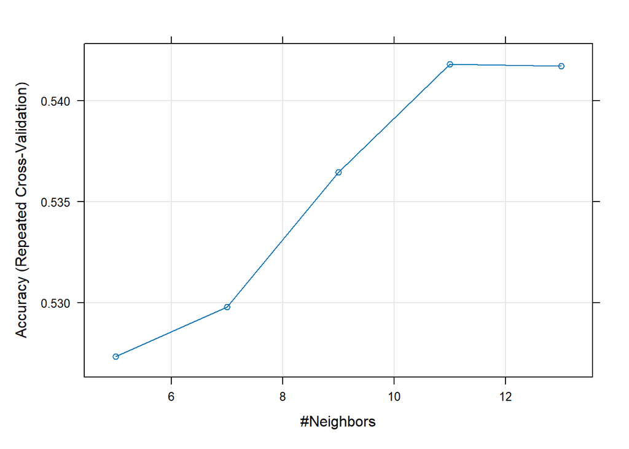

```r
plot(knnFit)
```

```r
knnPredict <- predict(knnFit,newdata = testData)
knnPredict
```

```
##  [1] 0 1 0 0 0 0 0 0 0 0 0 0 2 0 0 0 0 0 0 0 0 0 0 0 0 0 0 0 0 0 0 0 0 0 0 0 0 0
## [39] 0 0 0 0 0 0 0 0 0 0 0 0 0 0 0 0 0 0 0 0 0 0
## Levels: 0 1 2 3 4
```

```r
#Get the confusion matrix to see accuracy value and other parameter values
confusionMatrix(knnPredict, testData$Target)
```

```
## Confusion Matrix and Statistics
##
##           Reference
## Prediction  0  1  2  3  4
##          0 31 14  4  6  3
##          1  0  1  0  0  0
##          2  0  0  1  0  0
##          3  0  0  0  0  0
##          4  0  0  0  0  0
##
## Overall Statistics
##
##                Accuracy : 0.55
##                  95% CI : (0.4161, 0.6788)
##     No Information Rate : 0.5167
##     P-Value [Acc > NIR] : 0.3498
##
##                   Kappa : 0.0909
##
##  Mcnemar's Test P-Value : NA
##
## Statistics by Class:
##
##                      Class: 0 Class: 1 Class: 2 Class: 3 Class: 4
## Sensitivity           1.00000  0.06667  0.20000      0.0     0.00
## Specificity           0.06897  1.00000  1.00000      1.0     1.00
## Pos Pred Value        0.53448  1.00000  1.00000      NaN      NaN
## Neg Pred Value        1.00000  0.76271  0.93220      0.9     0.95
## Prevalence            0.51667  0.25000  0.08333      0.1     0.05
## Detection Rate        0.51667  0.01667  0.01667      0.0     0.00
## Detection Prevalence  0.96667  0.01667  0.01667      0.0     0.00
## Balanced Accuracy     0.53448  0.53333  0.60000      0.5     0.50
```

## J. Algoritma SVM

### Step) Membuat training data dan melakukan perubahan factor pada kolom Target

```r
#memanggil data training
trainData <- read.csv("D:\\KULIAH\\Dataset\\Pen data\\heart_disease_dataset.csv")
trainData$Target <- as.factor(trainData$Target)

str(trainData)
```

```
## 'data.frame':    303 obs. of  14 variables:
##  $ Age     : int  63 67 67 37 41 56 62 57 63 53 ...
##  $ Sex     : int  1 1 1 1 0 1 0 0 1 1 ...
##  $ CP      : int  1 4 4 3 2 2 4 4 4 4 ...
##  $ Trestbps: int  145 160 120 130 130 120 140 120 130 140 ...
##  $ Chol    : int  233 286 229 250 204 236 268 354 254 203 ...
##  $ Fbs     : int  1 0 0 0 0 0 0 0 0 1 ...
##  $ Restecg : int  2 2 2 0 2 0 2 0 2 2 ...
##  $ Thalach : int  150 108 129 187 172 178 160 163 147 155 ...
##  $ Exang   : int  0 1 1 0 0 0 0 1 0 1 ...
##  $ Oldpeak : num  2.3 1.5 2.6 3.5 1.4 0.8 3.6 0.6 1.4 3.1 ...
##  $ Slope   : int  3 2 2 3 1 1 3 1 2 3 ...
##  $ Ca      : int  0 3 2 0 0 0 2 0 1 0 ...
##  $ Thal    : int  6 3 7 3 3 3 3 3 7 7 ...
##  $ Target  : Factor w/ 5 levels "0","1","2","3",..: 1 3 2 1 1 1 4 1 3 2 ...
```

```r
trainData
```

```
##     Age Sex CP Trestbps Chol Fbs Restecg Thalach Exang Oldpeak Slope Ca Thal
## 1    63   1  1      145  233   1       2     150     0     2.3     3  0    6
## 2    67   1  4      160  286   0       2     108     1     1.5     2  3    3
## 3    67   1  4      120  229   0       2     129     1     2.6     2  2    7
## 4    37   1  3      130  250   0       0     187     0     3.5     3  0    3
## 5    41   0  2      130  204   0       2     172     0     1.4     1  0    3
## 6    56   1  2      120  236   0       0     178     0     0.8     1  0    3
## 7    62   0  4      140  268   0       2     160     0     3.6     3  2    3
## 8    57   0  4      120  354   0       0     163     1     0.6     1  0    3
## 9    63   1  4      130  254   0       2     147     0     1.4     2  1    7
## 10   53   1  4      140  203   1       2     155     1     3.1     3  0    7
## 11   57   1  4      140  192   0       0     148     0     0.4     2  0    6
## 12   56   0  2      140  294   0       2     153     0     1.3     2  0    3
## 13   56   1  3      130  256   1       2     142     1     0.6     2  1    6
## 14   44   1  2      120  263   0       0     173     0     0.0     1  0    7
```

[output cut: 593 more lines]

### Step) Membuat testing data dan melakukan perubahan factor pada kolom Target

```r
#memanggil data testing
testData <- read.csv("D:\\KULIAH\\Dataset\\Pen data\\testData.csv")
testData$Target <- factor(testData$Target)

str(testData)
```

```
## 'data.frame':    60 obs. of  14 variables:
##  $ Age     : int  67 67 56 57 48 49 69 60 44 59 ...
##  $ Sex     : int  1 1 1 1 0 1 0 1 1 1 ...
##  $ CP      : int  4 4 3 3 3 2 1 4 3 3 ...
##  $ Trestbps: int  160 120 130 150 130 130 140 117 130 150 ...
##  $ Chol    : int  286 229 256 168 275 266 239 230 233 212 ...
##  $ Fbs     : int  0 0 1 0 0 0 0 1 0 1 ...
##  $ Restecg : int  2 2 2 0 0 0 0 0 0 0 ...
##  $ Thalach : int  108 129 142 174 139 171 151 160 179 157 ...
##  $ Exang   : int  1 1 1 0 0 0 0 1 1 0 ...
##  $ Oldpeak : num  1.5 2.6 0.6 1.6 0.2 0.6 1.8 1.4 0.4 1.6 ...
##  $ Slope   : int  2 2 2 1 1 1 1 1 1 1 ...
##  $ Ca      : int  3 2 1 0 0 0 2 2 0 0 ...
##  $ Thal    : int  3 7 6 3 3 3 3 7 3 3 ...
##  $ Target  : Factor w/ 5 levels "0","1","2","3",..: 3 2 3 1 1 1 1 3 1 1 ...
```

```r
testData
```

```
##    Age Sex CP Trestbps Chol Fbs Restecg Thalach Exang Oldpeak Slope Ca Thal
## 1   67   1  4      160  286   0       2     108     1     1.5     2  3    3
## 2   67   1  4      120  229   0       2     129     1     2.6     2  2    7
## 3   56   1  3      130  256   1       2     142     1     0.6     2  1    6
## 4   57   1  3      150  168   0       0     174     0     1.6     1  0    3
## 5   48   0  3      130  275   0       0     139     0     0.2     1  0    3
## 6   49   1  2      130  266   0       0     171     0     0.6     1  0    3
## 7   69   0  1      140  239   0       0     151     0     1.8     1  2    3
## 8   60   1  4      117  230   1       0     160     1     1.4     1  2    7
## 9   44   1  3      130  233   0       0     179     1     0.4     1  0    3
## 10  59   1  3      150  212   1       0     157     0     1.6     1  0    3
## 11  58   1  3      112  230   0       2     165     0     2.5     2  1    7
## 12  54   1  4      124  266   0       2     109     1     2.2     2  1    7
## 13  60   1  4      145  282   0       2     142     1     2.8     2  2    7
## 14  65   0  3      155  269   0       0     148     0     0.8     1  0    3
```

[output cut: 107 more lines]

### Step: Membangun model

untuk membangun model, gunakan fungsi **SVM** dari library **e1071**.

```r
library(e1071)

svmfit <- svm(formula = Target ~ Age+Sex+CP+Trestbps+Chol+Fbs+Restecg+Thalach+Exang+Oldpeak+Slope+Ca+Thal,
              data = trainData,
              type = 'C-classification',
              kernel = 'linear',
              cost = 10,
              scale = TRUE)
```

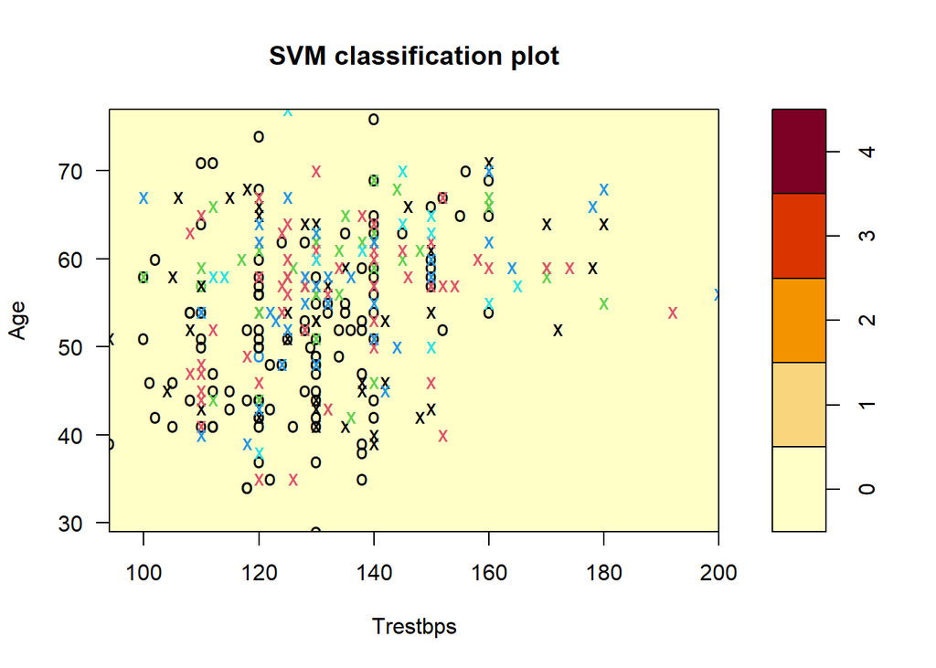

```r
plot(svmfit, trainData, Age ~ Trestbps)
```

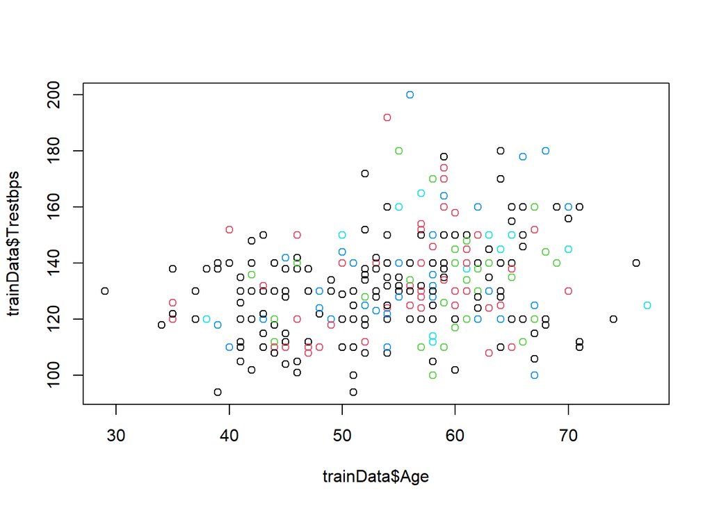

```r
plot(trainData$Age, trainData$Trestbps, col = trainData$Target)
```

### Step: Membuat prediksi

Untuk membuat prediksi, menggunakan fungsi **predict()**.

```r
#menghitung akurasi
library(caret)
```

```r
test_pred <- predict(svmfit,newdata=testData)
test_pred
```

```
##  1  2  3  4  5  6  7  8  9 10 11 12 13 14 15 16 17 18 19 20 21 22 23 24 25 26
##  2  3  2  0  0  0  0  2  0  0  1  3  4  0  0  2  4  0  0  2  0  2  0  0  0  0
## 27 28 29 30 31 32 33 34 35 36 37 38 39 40 41 42 43 44 45 46 47 48 49 50 51 52
##  0  2  0  0  4  2  1  0  0  0  3  1  0  0  2  0  1  0  0  1  0  0  0  2  0  1
## 53 54 55 56 57 58 59 60
##  0  0  0  0  0  3  1  2
## Levels: 0 1 2 3 4
```

```r
confusionMatrix(table(test_pred,testData$Target))
```

```
## Confusion Matrix and Statistics
##
##
## test_pred  0  1  2  3  4
##         0 30  5  0  0  0
##         1  1  4  0  1  1
##         2  0  4  4  2  1
##         3  0  2  0  2  0
##         4  0  0  1  1  1
##
## Overall Statistics
##
##                Accuracy : 0.6833
##                  95% CI : (0.5504, 0.7974)
##     No Information Rate : 0.5167
##     P-Value [Acc > NIR] : 0.006575
##
##                   Kappa : 0.509
##
##  Mcnemar's Test P-Value : NA
##
## Statistics by Class:
##
##                      Class: 0 Class: 1 Class: 2 Class: 3 Class: 4
## Sensitivity            0.9677  0.26667  0.80000  0.33333  0.33333
## Specificity            0.8276  0.93333  0.87273  0.96296  0.96491
## Pos Pred Value         0.8571  0.57143  0.36364  0.50000  0.33333
## Neg Pred Value         0.9600  0.79245  0.97959  0.92857  0.96491
## Prevalence             0.5167  0.25000  0.08333  0.10000  0.05000
## Detection Rate         0.5000  0.06667  0.06667  0.03333  0.01667
## Detection Prevalence   0.5833  0.11667  0.18333  0.06667  0.05000
## Balanced Accuracy      0.8977  0.60000  0.83636  0.64815  0.64912
```

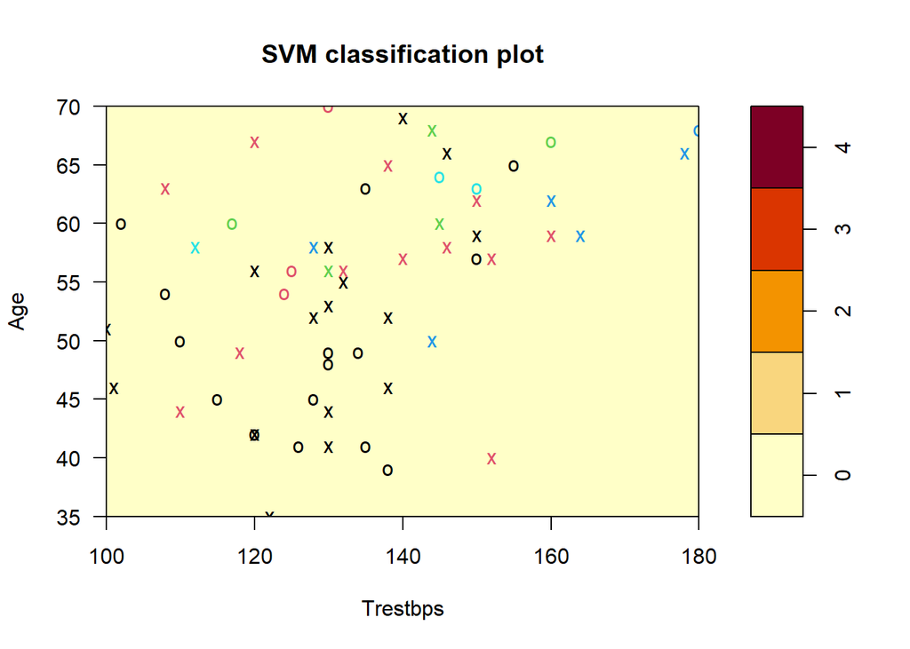

```r
plot(svmfit,data=testData,Age ~ Trestbps)
```

Berikut adalah akurasi dari setiap algoritma:

[output not shown]